# News Category Classification

News Category Classifier Python Notebook which was made using scikit-learn and NLTK libraries of Python. In this notebook, the News articles are classified into two categories:- "TRAVEL", "RELIGION"

```python
# Importing pandas package
import pandas as pandasForSortingCSV
# Importing the dependencies.
import nltk
import matplotlib
import numpy as np
from nltk import *
from nltk.corpus import stopwords
import pandas as pd
import matplotlib.pyplot as plt
import pandas as pd
import seaborn as sns
import re
nltk.download('punkt')
nltk.download('stopwords')
nltk.download('wordnet')
from sklearn.preprocessing import LabelEncoder
from sklearn.model_selection import GridSearchCV
from sklearn.model_selection import train_test_split
from sklearn.feature_extraction.text import TfidfVectorizer
from gensim.models import Word2Vec
from sklearn.pipeline import Pipeline
from sklearn.svm import SVC
from sklearn.naive_bayes import GaussianNB
from sklearn.naive_bayes import MultinomialNB
from sklearn.tree import DecisionTreeClassifier
from sklearn.neural_network import MLPClassifier
from sklearn.ensemble import GradientBoostingClassifier
from sklearn.metrics import precision_score, recall_score, f1_score, accuracy_score
import warnings
warnings.filterwarnings("ignore")
# from wordcloud import WordCloud
%matplotlib inline
plt.rcParams['figure.figsize'] = (8,6)
from sklearn.feature_extraction.text import TfidfVectorizer
from sklearn.feature_selection import chi2
import numpy as np
from nltk.corpus import stopwords
from sklearn.ensemble import RandomForestClassifier
from sklearn.neighbors import KNeighborsClassifier
from sklearn.tree import DecisionTreeClassifier
from sklearn.naive_bayes import MultinomialNB
# to convert the text into vectors
from sklearn.feature_extraction.text import TfidfVectorizer
from sklearn.model_selection import train_test_split
from sklearn.metrics import accuracy_score, classification_report, f1_score, confusion_matrix
import pickle
from pickle import dump
import seaborn as sns
import matplotlib.pyplot as plt
import pandas as pd
from IPython.display import display_html
import nltk
nltk.download('omw-1.4')
from sklearn.model_selection import KFold
from sklearn.model_selection import cross_val_score
import numpy as np # linear algebra
import pandas as pd # data processing, CSV file I/O
import matplotlib.pyplot as plt
plt.rcParams['figure.figsize'] = (6,6)
from keras import backend as K
from tensorflow.keras.layers import Layer, InputSpec
from keras import initializers, regularizers, constraints
from keras.layers import Dense, Input, LSTM, Bidirectional, Activation, Conv1D, GRU, TimeDistributed
from keras.layers import Dropout, Embedding, GlobalMaxPooling1D, MaxPooling1D, Add, Flatten, SpatialDropout1D
from keras.layers import GlobalAveragePooling1D, BatchNormalization, concatenate
from keras.layers import Reshape, Concatenate, Lambda, Average
from keras.models import Sequential, Model, load_model
from keras.callbacks import ModelCheckpoint
from keras.initializers import Constant
from tensorflow.keras.layers import concatenate
from keras.preprocessing import sequence
from keras.preprocessing.text import Tokenizer, text_to_word_sequence
from keras.utils import np_utils
from sklearn.model_selection import train_test_split
from sklearn.metrics import confusion_matrix
import os
from tensorflow.keras.preprocessing import sequence
```

**TASK 1**

```python
# Loading dataset
df=pd.read_csv('20204585.csv',
                        encoding='Latin1',dtype=str)
df
```

|  | Unnamed: 0 | category | headline | authors | link | short_description | date |
| --- | --- | --- | --- | --- | --- | --- | --- |
| 0 | 0 | TRAVEL | The World's Ultimate 'Ski-cations': Exploring ... | HotelsCombined.com, Contributor\nHotel price c... | https://www.huffingtonpost.com/entry/the-world... | From world-famous celeb magnets to quirky and ... | 2014-02-05 |
| 1 | 1 | TRAVEL | Where to Be Daring and Go Baring This Halloween | Tom Mulhall, Contributor\nNude Recreation Spec... | https://www.huffingtonpost.com/entry/where-to-... | Halloween's the scariest time of year for kids... | 2013-10-26 |
| 2 | 2 | TRAVEL | Strange But True: 8 Out of the Ordinary Ski Areas | Liftopia, ContributorSki deals online - www.li... | https://www.huffingtonpost.com/entry/strange-b... | If you are looking for something a little diff... | 2015-02-26 |
| 3 | 3 | TRAVEL | Documenta 13: Disguising Documentary As Art | Olivia Katrandjian, Contributor\nJournalist an... | https://www.huffingtonpost.com/entry/documenta... | The 13th Documenta Festival has taken over Kas... | 2012-08-30 |
| 4 | 4 | TRAVEL | Where To Go This Winter | Fodor's, Contributor\nFodors.com | https://www.huffingtonpost.com/entry/where-to-... | Winter vacations don't always have to be synon... | 2013-12-04 |
| ... | ... | ... | ... | ... | ... | ... | ... |
| 7995 | 7995 | RELIGION | Muslim Teacher Found A Violent Islamophobic Me... | Carol Kuruvilla | https://www.huffingtonpost.com/entry/muslim-te... | âYour headscarf isnât allowed anymore. Why... | 2016-11-15 |
| 7996 | 7996 | TRAVEL | The World's 10 Most Expensive Plane Tickets Wi... | Hopper.com, ContributorThe flight-prediction a... | https://www.huffingtonpost.com/entry/the-world... | They are loaded with luxurious add-ons and bes... | 2015-05-27 |
| 7997 | 7997 | TRAVEL | New U.S. Literary Tourism Goes Beyond 'The Hun... | Reuters, Reuters | https://www.huffingtonpost.com/entry/new-us-li... | "The author is from Jackson, and the book is s... | 2012-04-22 |
| 7998 | 7998 | TRAVEL | Up For A Challenge? Try These Outdoor Adventur... | Karen Schaler, Contributor\nEmmy award-winning... | https://www.huffingtonpost.com/entry/up-for-a-... | I love chilling out at the beach or a spa as m... | 2012-05-30 |
| 7999 | 7999 | RELIGION | Church Cross Saves Woman And Grandson Caught I... | Ron Dicker | https://www.huffingtonpost.com/entry/cross-sal... | "I said, 'dear Lord are you taking me home rig... | 2015-10-08 |

8000 rows × 7 columns

```python
df.groupby('category').category.count() #Calculating the count for both the news categories
```

```
category
RELIGION    1994
TRAVEL      5986
Name: category, dtype: int64
```

```
NUMBER OF SAMPLES IN EACH CATEGORY:
```

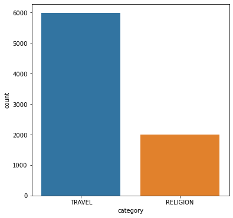

```python
print('NUMBER OF SAMPLES IN EACH CATEGORY: \n')
sns.countplot(df.category) #Plotting a bar graph to visualize the number of samples in each news category
```

```python
#Calculating the length of Headlines per row
df['news_length'] = df['headline'].str.len()
df['news_length']
```

```
0       73.0
1       47.0
2       49.0
3       43.0
4       23.0
        ...
7995    68.0
7996    62.0
7997    56.0
7998    56.0
7999    53.0
Name: news_length, Length: 8000, dtype: float64
```

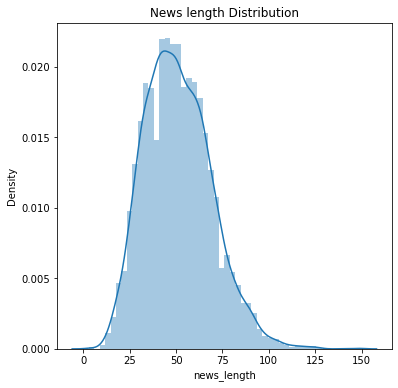

```python
sns.distplot(df['news_length']).set_title('News length Distribution')#plotting News Length for visualization
```

## Exploration of the Data

Natural Language Toolkit is used to conduct numerous operations for text data preparation such as tokenization, stopword removal, stemming, and so on.

```python
#Getting the category values, in my case there are two categories.
#Dividing the data into two dataframes
rTravel = df[df['category'] == 'TRAVEL']
rReligion = df[df['category'] == 'RELIGION']

#Converting from dataframe to list
rTravel['headline'].values.tolist()
rReligion['headline'].values.tolist()

#Method to convert list to String

def listToString(s):
    str1=" "
    return(str1.join(s))
```

The goal of data preparation is to convert data into the finest machine learning format possible. It is critical to clean the data because the model only learns from that data, so if we feed inconsistent, inappropriate data to the model, it will only return junk, so it is required to ensure that the data does not contain any unseen problem.

```python
# Tokenizing and converting the data to lowercase
tokensTravel = nltk.word_tokenize(str(rTravel['headline'].values.tolist()))
tokenReligion= nltk.word_tokenize(str(rReligion['headline'].values.tolist()))
tokensTravelLowerCase = [t.lower() for t in tokensTravel]
tokenReligionLowerCase= [t.lower() for t in tokenReligion]

# Removing punctuations from the data

removepuncTravel = [t for t in tokensTravelLowerCase if t.isalnum()]
removePuncReligion=[t for t in tokenReligionLowerCase if t.isalnum()]

# Removing stop words from the data
# stop words are words such as "a", "his", "that", & "and"
# that do not contribute to the underlying topic or classification of the text and therefore should be filtered out.
# Because there are fewer and only relevant words remaining, stopword elimination may help improve performance.
# As a result, the classification accuracy could be improved.
removeStopWordsTravel = [t for t in removepuncTravel if t not in stopwords.words('english')]
removeStopWordsReligion= [t for t in removePuncReligion if t not in stopwords.words('english')]
```

```python
#Method to find the Frequency Distribution for most common words used
#We use frequency distribution to visualize or illustrate the data collected in a sample.
#For Travel News Category

def findFrequencyDistribution(data,number):
    from nltk.probability import FreqDist
    fdist_f = FreqDist(removeStopWordsTravel)
    return fdist_f.most_common(number)


print(findFrequencyDistribution(removeStopWordsTravel,100))
```

```
[('photos', 1052), ('travel', 555), ('world', 377), ('best', 321), ('new', 250), ('5', 227), ('video', 199), ('hotel', 185), ('hotels', 170), ('america', 159), ('10', 152), ('7', 127), ('vacation', 126), ('day', 123), ('around', 120), ('things', 115), ('trip', 114), ('airlines', 110), ('places', 109…
```

```python
#For Religion News Category
def findFrequencyDistribution(data,number):
    from nltk.probability import FreqDist
    fdist_f = FreqDist(removeStopWordsReligion)
    return fdist_f.most_common(number)
print(findFrequencyDistribution(removeStopWordsReligion,50))
```

```
[('pope', 131), ('francis', 114), ('meditation', 109), ('church', 93), ('muslim', 70), ('faith', 63), ('religious', 62), ('new', 58), ('god', 58), ('christian', 49), ('catholic', 49), ('world', 47), ('trump', 45), ('religion', 44), ('jesus', 40), ('muslims', 40), ('people', 39), ('american', 38), ('…
```

Calculating average length of sentences.

```python
#Analysis of length of sentences in each category
#Method for calculating average length of sentences
def get_average_sentence_length(text):
    sentences = text.split(",")
    words = text.split(" ")
    if(sentences[len(sentences)-1]==""):
        average_sentence_length = len(words)/len(sentences)-1
    else:
        average_sentence_length = len(words)/len(sentences)
    return average_sentence_length
#https://python-forum.io/thread-11585.html
```

```python
avgTravel=get_average_sentence_length(str(rTravel['headline'].values.tolist()))
avgReligion=get_average_sentence_length(str(rReligion['headline'].values.tolist()))
```

```python
#Average length of sentences in Travel Category :7.08
print(avgTravel)
```

```
7.0825256556442415
```

```python
#Average length of sentences in Religion Category :7.63
print(avgReligion)
```

```
7.631463628396144
```

```python
#wordcloud for frequent words
from PIL import Image
from wordcloud import WordCloud, ImageColorGenerator
from os import path
%matplotlib inline
```

Using a wordcloud data visualization approach to show text data in which the size of each word signifies its frequency or relevance.

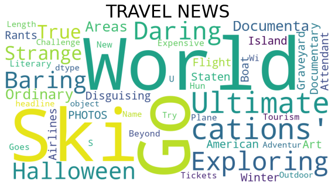

```python
travel = df[df['category'] == 'TRAVEL']
wordcloud = WordCloud(background_color="white", width = 1000, height = 500).generate(''.join(str(travel["headline"])))
plt.figure(figsize=(10,7))
plt.imshow(wordcloud)
plt.title("TRAVEL NEWS", fontsize=30)
plt.axis("off")
plt.show()
#https://github.com/adonovan7/BBCNewsClassification/blob/master/News_Classification_Project_Final_Draft.ipynb
```

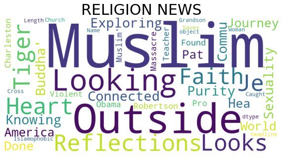

```python
religion = df[df['category'] == 'RELIGION']
wordcloud = WordCloud(background_color="white", width = 1000, height = 500).generate(''.join(str(religion["headline"])))
plt.figure(figsize=(10,7))
plt.imshow(wordcloud)
plt.title("RELIGION NEWS", fontsize=30)
plt.axis("off")
plt.show()
```

**Machine learning algorithms cannot work on the raw text directly. So, we need some feature extraction techniques to convert text into a matrix(or vector) of features.**

```python
#comparing against label - against category
```

```python
df = df.dropna() #The pandas dropna function allows us to drop rows & columns that contain missing values.
```

```python
df.isnull().any()
```

```
Unnamed: 0           False
category             False
headline             False
authors              False
link                 False
short_description    False
date                 False
news_length          False
dtype: bool
```

```python
#Associating Category names with numerical index and save it in new column category_id
df['category_id']= df.category.astype("category").cat.codes
df['category_id'] = df['category_id'].astype(float)
df
```

|  | Unnamed: 0 | category | headline | authors | link | short_description | date | news_length | category_id |
| --- | --- | --- | --- | --- | --- | --- | --- | --- | --- |
| 0 | 0 | TRAVEL | The World's Ultimate 'Ski-cations': Exploring ... | HotelsCombined.com, Contributor\nHotel price c... | https://www.huffingtonpost.com/entry/the-world... | From world-famous celeb magnets to quirky and ... | 2014-02-05 | 73.0 | 1.0 |
| 1 | 1 | TRAVEL | Where to Be Daring and Go Baring This Halloween | Tom Mulhall, Contributor\nNude Recreation Spec... | https://www.huffingtonpost.com/entry/where-to-... | Halloween's the scariest time of year for kids... | 2013-10-26 | 47.0 | 1.0 |
| 2 | 2 | TRAVEL | Strange But True: 8 Out of the Ordinary Ski Areas | Liftopia, ContributorSki deals online - www.li... | https://www.huffingtonpost.com/entry/strange-b... | If you are looking for something a little diff... | 2015-02-26 | 49.0 | 1.0 |
| 3 | 3 | TRAVEL | Documenta 13: Disguising Documentary As Art | Olivia Katrandjian, Contributor\nJournalist an... | https://www.huffingtonpost.com/entry/documenta... | The 13th Documenta Festival has taken over Kas... | 2012-08-30 | 43.0 | 1.0 |
| 4 | 4 | TRAVEL | Where To Go This Winter | Fodor's, Contributor\nFodors.com | https://www.huffingtonpost.com/entry/where-to-... | Winter vacations don't always have to be synon... | 2013-12-04 | 23.0 | 1.0 |
| ... | ... | ... | ... | ... | ... | ... | ... | ... | ... |
| 7995 | 7995 | RELIGION | Muslim Teacher Found A Violent Islamophobic Me... | Carol Kuruvilla | https://www.huffingtonpost.com/entry/muslim-te... | âYour headscarf isnât allowed anymore. Why... | 2016-11-15 | 68.0 | 0.0 |
| 7996 | 7996 | TRAVEL | The World's 10 Most Expensive Plane Tickets Wi... | Hopper.com, ContributorThe flight-prediction a... | https://www.huffingtonpost.com/entry/the-world... | They are loaded with luxurious add-ons and bes... | 2015-05-27 | 62.0 | 1.0 |
| 7997 | 7997 | TRAVEL | New U.S. Literary Tourism Goes Beyond 'The Hun... | Reuters, Reuters | https://www.huffingtonpost.com/entry/new-us-li... | "The author is from Jackson, and the book is s... | 2012-04-22 | 56.0 | 1.0 |
| 7998 | 7998 | TRAVEL | Up For A Challenge? Try These Outdoor Adventur... | Karen Schaler, Contributor\nEmmy award-winning... | https://www.huffingtonpost.com/entry/up-for-a-... | I love chilling out at the beach or a spa as m... | 2012-05-30 | 56.0 | 1.0 |
| 7999 | 7999 | RELIGION | Church Cross Saves Woman And Grandson Caught I... | Ron Dicker | https://www.huffingtonpost.com/entry/cross-sal... | "I said, 'dear Lord are you taking me home rig... | 2015-10-08 | 53.0 | 0.0 |

6152 rows × 9 columns

```python
df['category_id'].unique()
```

```
array([1., 0.])
```

```python
df['category_id']
```

```
0       1.0
1       1.0
2       1.0
3       1.0
4       1.0
       ...
7995    0.0
7996    1.0
7997    1.0
7998    1.0
7999    0.0
Name: category_id, Length: 6152, dtype: float64
```

```python
category_id_df = df[['category', 'category_id']].drop_duplicates().sort_values('category_id')
```

```python
category_id_df
```

|  | category | category_id |
| --- | --- | --- |
| 8 | RELIGION | 0.0 |
| 0 | TRAVEL | 1.0 |

```python
category_to_id = dict(category_id_df.values)
id_to_category = dict(category_id_df[['category_id', 'category']].values)
```

```python
id_to_category
```

```
{0.0: 'RELIGION', 1.0: 'TRAVEL'}
```

```python
from sklearn.feature_extraction.text import TfidfVectorizer
tfidf = TfidfVectorizer(sublinear_tf=True, min_df=5, norm='l2', encoding='latin-1', ngram_range=(1, 2), stop_words='english')
features = tfidf.fit_transform(df.headline).toarray()
labels = df.category_id
```

```python
features.shape
```

```
(6152, 1595)
```

```python
category_to_id.items()
```

```
dict_items([('RELIGION', 0.0), ('TRAVEL', 1.0)])
```

```python
sorted(category_to_id.items())
```

```
[('RELIGION', 0.0), ('TRAVEL', 1.0)]
```

Feature Selection

Chi Square is a statistical technique, used for calculating correlation of features with outcome. The chi-square test helps you to solve the problem in feature selection by testing the relationship between the features.

```python
from sklearn.feature_selection import chi2
import numpy as np
N = 2
for category, category_id in sorted(category_to_id.items()):
  features_chi2 = chi2(features, labels == category_id)
  indices = np.argsort(features_chi2[0])
  feature_names = np.array(tfidf.get_feature_names())[indices]
  unigrams = [v for v in feature_names if len(v.split(' ')) == 1]
  bigrams = [v for v in feature_names if len(v.split(' ')) == 2]
  print("# '{}':".format(category))
  print("  . Most correlated unigrams:\n. {}".format('\n. '.join(unigrams[-N:])))
  print("  . Most correlated bigrams:\n. {}".format('\n. '.join(bigrams[-N:])))
```

```
# 'RELIGION':
  . Most correlated unigrams:
. daily
. pope
  . Most correlated bigrams:
. pope francis
. daily meditation
# 'TRAVEL':
  . Most correlated unigrams:
. daily
. pope
  . Most correlated bigrams:
. pope francis
. daily meditation
```

```python
X = df.loc[:,df.columns != 'category'] #storing all the columns except category in the variable X
```

```python
X.drop('Unnamed: 0', axis=1, inplace=True) #dropping the column unnamed:0
```

```python
X
```

|  | headline | authors | link | short_description | date | news_length | category_id |
| --- | --- | --- | --- | --- | --- | --- | --- |
| 0 | The World's Ultimate 'Ski-cations': Exploring ... | HotelsCombined.com, Contributor\nHotel price c... | https://www.huffingtonpost.com/entry/the-world... | From world-famous celeb magnets to quirky and ... | 2014-02-05 | 73.0 | 1.0 |
| 1 | Where to Be Daring and Go Baring This Halloween | Tom Mulhall, Contributor\nNude Recreation Spec... | https://www.huffingtonpost.com/entry/where-to-... | Halloween's the scariest time of year for kids... | 2013-10-26 | 47.0 | 1.0 |
| 2 | Strange But True: 8 Out of the Ordinary Ski Areas | Liftopia, ContributorSki deals online - www.li... | https://www.huffingtonpost.com/entry/strange-b... | If you are looking for something a little diff... | 2015-02-26 | 49.0 | 1.0 |
| 3 | Documenta 13: Disguising Documentary As Art | Olivia Katrandjian, Contributor\nJournalist an... | https://www.huffingtonpost.com/entry/documenta... | The 13th Documenta Festival has taken over Kas... | 2012-08-30 | 43.0 | 1.0 |
| 4 | Where To Go This Winter | Fodor's, Contributor\nFodors.com | https://www.huffingtonpost.com/entry/where-to-... | Winter vacations don't always have to be synon... | 2013-12-04 | 23.0 | 1.0 |
| ... | ... | ... | ... | ... | ... | ... | ... |
| 7995 | Muslim Teacher Found A Violent Islamophobic Me... | Carol Kuruvilla | https://www.huffingtonpost.com/entry/muslim-te... | âYour headscarf isnât allowed anymore. Why... | 2016-11-15 | 68.0 | 0.0 |
| 7996 | The World's 10 Most Expensive Plane Tickets Wi... | Hopper.com, ContributorThe flight-prediction a... | https://www.huffingtonpost.com/entry/the-world... | They are loaded with luxurious add-ons and bes... | 2015-05-27 | 62.0 | 1.0 |
| 7997 | New U.S. Literary Tourism Goes Beyond 'The Hun... | Reuters, Reuters | https://www.huffingtonpost.com/entry/new-us-li... | "The author is from Jackson, and the book is s... | 2012-04-22 | 56.0 | 1.0 |
| 7998 | Up For A Challenge? Try These Outdoor Adventur... | Karen Schaler, Contributor\nEmmy award-winning... | https://www.huffingtonpost.com/entry/up-for-a-... | I love chilling out at the beach or a spa as m... | 2012-05-30 | 56.0 | 1.0 |
| 7999 | Church Cross Saves Woman And Grandson Caught I... | Ron Dicker | https://www.huffingtonpost.com/entry/cross-sal... | "I said, 'dear Lord are you taking me home rig... | 2015-10-08 | 53.0 | 0.0 |

6152 rows × 7 columns

```python
ytarget = df['category']
```

```python
ytarget
```

```
0         TRAVEL
1         TRAVEL
2         TRAVEL
3         TRAVEL
4         TRAVEL
          ...
7995    RELIGION
7996      TRAVEL
7997      TRAVEL
7998      TRAVEL
7999    RELIGION
Name: category, Length: 6152, dtype: object
```

```python
ytarget.isnull().any()
```

```
False
```

**TASK 2 and TASK 3**

Now we would be doing the train-test split using the 80:20 rule where 80% of the data goes to training and the rest 20% goes to testing.

Splitting the entire dataset into three parts: Training-55%, Validation-25% and Testing-20%.

Training Set: Set of data that is used to train and make the model learn the hidden features/patterns in the data.

Validation Set: Set of data, separate from the training set, that is used to validate our model performance during training.

Testing Set: Set of data used to test the model after completing the training.It provides an unbiased final model performance metric in terms of accuracy, precision, etc.

```python
X_train_plus_valid, X_test, y_train_plus_valid, y_test = train_test_split(X, ytarget, random_state=0, test_size = 0.20, train_size = 0.8)
X_train, X_valid, y_train, y_valid = train_test_split(X_train_plus_valid, y_train_plus_valid, random_state=0, test_size = 0.25/0.8, train_size = 0.55/0.8)
```

```python
X_train_plus_valid
```

|  | headline | authors | link | short_description | date | news_length | category_id |
| --- | --- | --- | --- | --- | --- | --- | --- |
| 7194 | Jesus Loves Trump, But He Wouldn't Vote For Him | Kimberly Poovey, ContributorWriter, speaker, ... | https://www.huffingtonpost.com/entry/jesus-lov... | I believe with all my heart that Jesus loves D... | 2016-10-08 | 47.0 | 0.0 |
| 7004 | Track Records: A Walk Around The Hutongs of Be... | Benedict Cooper, Contributor\nFreelance writer | https://www.huffingtonpost.com/entry/track-rec... | I was expecting big, hot and busy when I set o... | 2012-08-22 | 51.0 | 1.0 |
| 7146 | Russia May Crack Down On Duty-Free Alcohol Tha... | Reuters, Reuters | https://www.huffingtonpost.com/entry/russia-ey... | "Changes are needed to end such uproar on plan... | 2013-02-04 | 69.0 | 1.0 |
| 3100 | PHOTOS: A Royal Favorite In Jamaica | Elizabeth Thorp, Contributor\nJournalist, Trav... | https://www.huffingtonpost.com/entry/vacation-... | As part of Prince Henry's recent tour of Jamai... | 2012-03-15 | 35.0 | 1.0 |
| 7098 | Cal Jet Makes Sunny Mazatlan Accessible | Anne Z. Cooke, Contributor\nTravel & Feature J... | https://www.huffingtonpost.com/entry/cal-jet-m... | Mazatlan is the place where I've wiggled my to... | 2013-01-19 | 39.0 | 1.0 |
| ... | ... | ... | ... | ... | ... | ... | ... |
| 6398 | 6 B&B Wineries Uncorking Full-Bodied Fun (PHOTOS) | BnBFinder.com, Contributor\nBnBFinder | https://www.huffingtonpost.com/entry/fullbodie... | With the arrival of fall comes the wine harves... | 2012-09-12 | 49.0 | 1.0 |
| 4218 | Drink the World: Peru | Dan Miles, Contributor\nBest Selling Author of... | https://www.huffingtonpost.com/entry/drink-the... | My head punished me for every single drop the ... | 2014-03-20 | 21.0 | 1.0 |
| 2186 | 10 Practical Carry-On Bags That Attach To Your... | Brittany Nims | https://www.huffingtonpost.com/entry/carry-on-... | Look for carry-on bags with "trolley sleeves" ... | 2018-03-02 | 55.0 | 1.0 |
| 3384 | Guinea-Bissau: Travels in One of Africa's Poor... | Rachel Stern, Contributor\nBerlin-based journa... | https://www.huffingtonpost.com/entry/travels-i... | Damaged by a civil war in the late 1990s, Guin... | 2013-08-15 | 59.0 | 1.0 |
| 3540 | Great (But Forgotten) Historic Sites Linked to... | Andrew Carroll, Contributor\nAuthor, 'Here Is ... | https://www.huffingtonpost.com/entry/fathers-d... | In honor of this Father's Day, I picked out my... | 2013-06-14 | 91.0 | 1.0 |

4921 rows × 7 columns

```python
y_train_plus_valid
```

```
7194    RELIGION
7004      TRAVEL
7146      TRAVEL
3100      TRAVEL
7098      TRAVEL
          ...
6398      TRAVEL
4218      TRAVEL
2186      TRAVEL
3384      TRAVEL
3540      TRAVEL
Name: category, Length: 4921, dtype: object
```

```python
X_test
```

|  | headline | authors | link | short_description | date | news_length | category_id |
| --- | --- | --- | --- | --- | --- | --- | --- |
| 869 | Only One Resolution This Year | Rabbi Ted Falcon, ContributorSpiritual guide, ... | https://www.huffingtonpost.com/entry/only-one-... | The problem with resolutions is that they prop... | 2015-01-03 | 29.0 | 0.0 |
| 3361 | 11 Insanely Beautiful Bodies Of Water (PHOTOS) | Lisa_Miller | https://www.huffingtonpost.com/entry/beautiful... | It's pretty hard to beat sitting lakefront or ... | 2013-06-20 | 46.0 | 1.0 |
| 3655 | Vacation Escapes to Take Your Mind off Summer'... | Conde Nast Traveler, Contributor\nConde Nast T... | https://www.huffingtonpost.com/entry/vacation-... | A little depressed that summer's winding down?... | 2013-09-09 | 51.0 | 1.0 |
| 4672 | Embracing The Tenderloin At The Urban Tavern | Anne Z. Cooke, Contributor\nTravel & Feature J... | https://www.huffingtonpost.com/entry/the-urban... | Urban Tavern is in the Tenderloin District, so... | 2012-04-16 | 44.0 | 1.0 |
| 6595 | The 12 Most Epic Sledding Hills On Earth | Cheapflights, Contributorwww.cheapflights.com | https://www.huffingtonpost.com/entry/top-12-ep... | Take advantage of all the wonderful things win... | 2015-02-26 | 40.0 | 1.0 |
| ... | ... | ... | ... | ... | ... | ... | ... |
| 1241 | 7 Things That'll Still Be True For Christians ... | Jason Foster, ContributorChristian journalist/... | https://www.huffingtonpost.com/entry/7-things-... | Take a deep breath. Say a prayer. Itâll all ... | 2016-11-06 | 84.0 | 0.0 |
| 1689 | So THAT'S Why Airplane Windows Are Round | Suzy Strutner | https://www.huffingtonpost.com/entry/plane-win... | It's #science. | 2016-01-20 | 40.0 | 1.0 |
| 4477 | The World's Best Antiques Fair Is in Texas | Fathom, Contributor\nGet inspired. Plan your t... | https://www.huffingtonpost.com/entry/the-world... | Twice a year in spring and autumn, people floc... | 2013-09-19 | 42.0 | 1.0 |
| 4755 | I Tried The Vegas Hangover Bus (PHOTOS) | Kaylee King, Contributor\nSenior Editor, Huffi... | https://www.huffingtonpost.com/entry/hangover-... | I hop onboard the bus and am immediately welco... | 2012-06-06 | 39.0 | 1.0 |
| 2795 | Cuddling a Koala in Australia | Andrea Poe, Contributor\nAndrea Poe is a journ... | https://www.huffingtonpost.com/entry/cuddling-... | Holding a koala is unlike anything you might e... | 2013-06-21 | 29.0 | 1.0 |

1231 rows × 7 columns

```python
y_test
```

```
869     RELIGION
3361      TRAVEL
3655      TRAVEL
4672      TRAVEL
6595      TRAVEL
          ...
1241    RELIGION
1689      TRAVEL
4477      TRAVEL
4755      TRAVEL
2795      TRAVEL
Name: category, Length: 1231, dtype: object
```

```python
X_train
```

|  | headline | authors | link | short_description | date | news_length | category_id |
| --- | --- | --- | --- | --- | --- | --- | --- |
| 5486 | SeaWorld Just Unveiled A New Plan To Win Back ... | Suzy Strutner | https://www.huffingtonpost.com/entry/seaworld-... | The "Blackfish Effect" is a lot to overcome. | 2016-09-27 | 85.0 | 1.0 |
| 7474 | The Nightlife In Marrakesh, Morocco | Go Ahead Tours, ContributorOffering 100+ tours... | https://www.huffingtonpost.com/entry/the-night... | Spending a night in Marrakesh will produce exp... | 2015-03-06 | 35.0 | 1.0 |
| 7827 | A Time of Vigilance in the Ukraine | Rabbi Michael Bernstein, ContributorCongregati... | https://www.huffingtonpost.com/entry/a-time-of... | We are challenged these days by the ugly remin... | 2014-04-19 | 34.0 | 0.0 |
| 7540 | Never Lose Your Luggage Again With These 4 Tips | U.S. News Travel, ContributorU.S. News & World... | https://www.huffingtonpost.com/entry/never-los... | If you're stuck at the airport looking at an e... | 2015-05-13 | 47.0 | 1.0 |
| 3399 | Rep. Keith Ellison Is Optimistic About America... | Jared Greenhouse | https://www.huffingtonpost.com/entry/keith-ell... | A recently released Gallup pollÂ showed that 6... | 2015-07-21 | 82.0 | 0.0 |
| ... | ... | ... | ... | ... | ... | ... | ... |
| 5284 | 7 Fashionable Hotels Around the World -- For E... | Oyster.com, Contributor\nThe Hotel Tell-All | https://www.huffingtonpost.com/entry/7-fashion... | Fashion Week has arrived to New York City, and... | 2013-09-09 | 56.0 | 1.0 |
| 3184 | 7 Reasons Your Next Vacation Should Be To A Ch... | Kate Auletta | https://www.huffingtonpost.com/entry/barrier-i... | Let's all take a minute and give a little prai... | 2015-04-17 | 63.0 | 1.0 |
| 1671 | Tourist's Comedy Gets Stone-Cold British Guard... | Ryan Grenoble | https://www.huffingtonpost.com/entry/guy-makes... | A YouTube video of the encounter opens with Ya... | 2014-03-12 | 63.0 | 1.0 |
| 2391 | What the Government Shutdown Means to Travelers | Travelzoo, Contributor\nA global Internet medi... | https://www.huffingtonpost.com/entry/what-the-... | With a government shutdown starting today, her... | 2013-10-01 | 47.0 | 1.0 |
| 3148 | What Travel Has Taught Me About 'Reality' | Robert Schrader, Contributor\nWriter, Photogra... | https://www.huffingtonpost.com/entry/what-trav... | Any individual's perception of reality is inex... | 2013-04-04 | 41.0 | 1.0 |

3383 rows × 7 columns

```python
y_train.isnull
```

```
<bound method Series.isnull of 5486      TRAVEL
7474      TRAVEL
7827    RELIGION
7540      TRAVEL
3399    RELIGION
          ...
5284      TRAVEL
3184      TRAVEL
1671      TRAVEL
2391      TRAVEL
3148      TRAVEL
Name: category, Length: 3383, dtype: object>
```

```python
X_valid
```

|  | headline | authors | link | short_description | date | news_length | category_id |
| --- | --- | --- | --- | --- | --- | --- | --- |
| 3443 | 5 of the Most Uber-Luxurious Suites in Las Vegas | Oyster.com, Contributor\nThe Hotel Tell-All | https://www.huffingtonpost.com/entry/5-of-the-... | Vegas is a city that is decidedly over-the-top... | 2013-07-09 | 48.0 | 1.0 |
| 2559 | Top 10 Travel Destinations For 2013 | Fly.com, Contributor\nFly.com | https://www.huffingtonpost.com/entry/top-10-tr... | Fly.com recently asked 875 U.S. travelers wher... | 2013-01-08 | 35.0 | 1.0 |
| 4517 | Bruges is Beyond Beautiful | Lev Raphael, Contributor\nAuthor, Reviewer, Bl... | https://www.huffingtonpost.com/entry/bruges-is... | Bruges this past month was perfect for the kin... | 2013-05-15 | 26.0 | 1.0 |
| 1047 | How Not to Be an Obnoxious Tourist With an Int... | Ben Colclough, Contributor\nAdventure travel e... | https://www.huffingtonpost.com/entry/obnoxious... | Do you ever take photographs of locals when yo... | 2013-04-03 | 59.0 | 1.0 |
| 4977 | Expert Answers To 10 Common Travel Questions | SmarterTravel, Contributor\nSmartertravel.com | https://www.huffingtonpost.com/entry/expert-an... | Should you wait to book? How do you spot a goo... | 2012-12-20 | 44.0 | 1.0 |
| ... | ... | ... | ... | ... | ... | ... | ... |
| 2509 | Lonely Planet's Top U.S. Destination Of 2018 I... | Abigail Williams | https://www.huffingtonpost.com/entry/top-desti... | Pack your bags! | 2018-02-06 | 70.0 | 1.0 |
| 4629 | Outrageously Lavish Hotel Suites | Conde Nast Traveler, Contributor\nConde Nast T... | https://www.huffingtonpost.com/entry/outrageou... | By Christian L. Wright, CondÃ© Nast Traveler M... | 2013-09-24 | 32.0 | 1.0 |
| 2555 | Notes From Nicaragua: Listo or Not | Joe Hutcheson, Contributor\nWriter, teacher, s... | https://www.huffingtonpost.com/entry/notes-fro... | Certainly the thought of zip-lining through th... | 2014-02-18 | 34.0 | 1.0 |
| 7846 | Guide To Willamette Valley Wine Country (PHOTOS) | Snooth, Contributor\nSnooth, the world's most ... | https://www.huffingtonpost.com/entry/guide-to-... | The northern portion of Oregon's Willamette Va... | 2012-09-13 | 48.0 | 1.0 |
| 3765 | Bernie Sanders Embodies Trend Of The 'Spiritua... | Antonia Blumberg | https://www.huffingtonpost.com/entry/bernie-sa... | Jane Sanders, the senator's wife, opened up ab... | 2016-02-11 | 75.0 | 0.0 |

1538 rows × 7 columns

```python
y_valid
```

```
3443      TRAVEL
2559      TRAVEL
4517      TRAVEL
1047      TRAVEL
4977      TRAVEL
          ...
2509      TRAVEL
4629      TRAVEL
2555      TRAVEL
7846      TRAVEL
3765    RELIGION
Name: category, Length: 1538, dtype: object
```

```python
X_test
```

|  | headline | authors | link | short_description | date | news_length | category_id |
| --- | --- | --- | --- | --- | --- | --- | --- |
| 869 | Only One Resolution This Year | Rabbi Ted Falcon, ContributorSpiritual guide, ... | https://www.huffingtonpost.com/entry/only-one-... | The problem with resolutions is that they prop... | 2015-01-03 | 29.0 | 0.0 |
| 3361 | 11 Insanely Beautiful Bodies Of Water (PHOTOS) | Lisa_Miller | https://www.huffingtonpost.com/entry/beautiful... | It's pretty hard to beat sitting lakefront or ... | 2013-06-20 | 46.0 | 1.0 |
| 3655 | Vacation Escapes to Take Your Mind off Summer'... | Conde Nast Traveler, Contributor\nConde Nast T... | https://www.huffingtonpost.com/entry/vacation-... | A little depressed that summer's winding down?... | 2013-09-09 | 51.0 | 1.0 |
| 4672 | Embracing The Tenderloin At The Urban Tavern | Anne Z. Cooke, Contributor\nTravel & Feature J... | https://www.huffingtonpost.com/entry/the-urban... | Urban Tavern is in the Tenderloin District, so... | 2012-04-16 | 44.0 | 1.0 |
| 6595 | The 12 Most Epic Sledding Hills On Earth | Cheapflights, Contributorwww.cheapflights.com | https://www.huffingtonpost.com/entry/top-12-ep... | Take advantage of all the wonderful things win... | 2015-02-26 | 40.0 | 1.0 |
| ... | ... | ... | ... | ... | ... | ... | ... |
| 1241 | 7 Things That'll Still Be True For Christians ... | Jason Foster, ContributorChristian journalist/... | https://www.huffingtonpost.com/entry/7-things-... | Take a deep breath. Say a prayer. Itâll all ... | 2016-11-06 | 84.0 | 0.0 |
| 1689 | So THAT'S Why Airplane Windows Are Round | Suzy Strutner | https://www.huffingtonpost.com/entry/plane-win... | It's #science. | 2016-01-20 | 40.0 | 1.0 |
| 4477 | The World's Best Antiques Fair Is in Texas | Fathom, Contributor\nGet inspired. Plan your t... | https://www.huffingtonpost.com/entry/the-world... | Twice a year in spring and autumn, people floc... | 2013-09-19 | 42.0 | 1.0 |
| 4755 | I Tried The Vegas Hangover Bus (PHOTOS) | Kaylee King, Contributor\nSenior Editor, Huffi... | https://www.huffingtonpost.com/entry/hangover-... | I hop onboard the bus and am immediately welco... | 2012-06-06 | 39.0 | 1.0 |
| 2795 | Cuddling a Koala in Australia | Andrea Poe, Contributor\nAndrea Poe is a journ... | https://www.huffingtonpost.com/entry/cuddling-... | Holding a koala is unlike anything you might e... | 2013-06-21 | 29.0 | 1.0 |

1231 rows × 7 columns

```python
y_valid
```

```
3443      TRAVEL
2559      TRAVEL
4517      TRAVEL
1047      TRAVEL
4977      TRAVEL
          ...
2509      TRAVEL
4629      TRAVEL
2555      TRAVEL
7846      TRAVEL
3765    RELIGION
Name: category, Length: 1538, dtype: object
```

```python
from sklearn.model_selection import train_test_split
#Creating three separate .csv files and saving the split dataset into it.
X_train.to_csv('train.csv',index=False)
X_valid.to_csv('valid.csv',index=False)
X_test.to_csv('test.csv',index=False)
```

Loading the Train Dataset

```python
#loading the train dataset for preprocessing steps
traindata = pd.read_csv("train.csv",header=0)
traindata
```

|  | headline | authors | link | short_description | date | news_length | category_id |
| --- | --- | --- | --- | --- | --- | --- | --- |
| 0 | SeaWorld Just Unveiled A New Plan To Win Back ... | Suzy Strutner | https://www.huffingtonpost.com/entry/seaworld-... | The "Blackfish Effect" is a lot to overcome. | 2016-09-27 | 85.0 | 1.0 |
| 1 | The Nightlife In Marrakesh, Morocco | Go Ahead Tours, ContributorOffering 100+ tours... | https://www.huffingtonpost.com/entry/the-night... | Spending a night in Marrakesh will produce exp... | 2015-03-06 | 35.0 | 1.0 |
| 2 | A Time of Vigilance in the Ukraine | Rabbi Michael Bernstein, ContributorCongregati... | https://www.huffingtonpost.com/entry/a-time-of... | We are challenged these days by the ugly remin... | 2014-04-19 | 34.0 | 0.0 |
| 3 | Never Lose Your Luggage Again With These 4 Tips | U.S. News Travel, ContributorU.S. News & World... | https://www.huffingtonpost.com/entry/never-los... | If you're stuck at the airport looking at an e... | 2015-05-13 | 47.0 | 1.0 |
| 4 | Rep. Keith Ellison Is Optimistic About America... | Jared Greenhouse | https://www.huffingtonpost.com/entry/keith-ell... | A recently released Gallup pollÂ showed that 6... | 2015-07-21 | 82.0 | 0.0 |
| ... | ... | ... | ... | ... | ... | ... | ... |
| 3378 | 7 Fashionable Hotels Around the World -- For E... | Oyster.com, Contributor\nThe Hotel Tell-All | https://www.huffingtonpost.com/entry/7-fashion... | Fashion Week has arrived to New York City, and... | 2013-09-09 | 56.0 | 1.0 |
| 3379 | 7 Reasons Your Next Vacation Should Be To A Ch... | Kate Auletta | https://www.huffingtonpost.com/entry/barrier-i... | Let's all take a minute and give a little prai... | 2015-04-17 | 63.0 | 1.0 |
| 3380 | Tourist's Comedy Gets Stone-Cold British Guard... | Ryan Grenoble | https://www.huffingtonpost.com/entry/guy-makes... | A YouTube video of the encounter opens with Ya... | 2014-03-12 | 63.0 | 1.0 |
| 3381 | What the Government Shutdown Means to Travelers | Travelzoo, Contributor\nA global Internet medi... | https://www.huffingtonpost.com/entry/what-the-... | With a government shutdown starting today, her... | 2013-10-01 | 47.0 | 1.0 |
| 3382 | What Travel Has Taught Me About 'Reality' | Robert Schrader, Contributor\nWriter, Photogra... | https://www.huffingtonpost.com/entry/what-trav... | Any individual's perception of reality is inex... | 2013-04-04 | 41.0 | 1.0 |

3383 rows × 7 columns

```python
#Data Preprocessing
#Converting all the data to lowercase
#It helps to maintain the consistency flow during the NLP tasks and text mining.
traindata = traindata.apply(lambda x: x.astype(str).str.lower())
```

```python
#Removing punctuations as they behave like noise in the text data since they have no semantic meaning.
traindata["headline"] = traindata['headline'].str.replace('[^\w\s]','')
```

```python
traindata
```

|  | headline | authors | link | short_description | date | news_length | category_id |
| --- | --- | --- | --- | --- | --- | --- | --- |
| 0 | seaworld just unveiled a new plan to win back ... | suzy strutner | https://www.huffingtonpost.com/entry/seaworld-... | the "blackfish effect" is a lot to overcome. | 2016-09-27 | 85.0 | 1.0 |
| 1 | the nightlife in marrakesh morocco | go ahead tours, contributoroffering 100+ tours... | https://www.huffingtonpost.com/entry/the-night... | spending a night in marrakesh will produce exp... | 2015-03-06 | 35.0 | 1.0 |
| 2 | a time of vigilance in the ukraine | rabbi michael bernstein, contributorcongregati... | https://www.huffingtonpost.com/entry/a-time-of... | we are challenged these days by the ugly remin... | 2014-04-19 | 34.0 | 0.0 |
| 3 | never lose your luggage again with these 4 tips | u.s. news travel, contributoru.s. news & world... | https://www.huffingtonpost.com/entry/never-los... | if you're stuck at the airport looking at an e... | 2015-05-13 | 47.0 | 1.0 |
| 4 | rep keith ellison is optimistic about american... | jared greenhouse | https://www.huffingtonpost.com/entry/keith-ell... | a recently released gallup pollâ showed that 6... | 2015-07-21 | 82.0 | 0.0 |
| ... | ... | ... | ... | ... | ... | ... | ... |
| 3378 | 7 fashionable hotels around the world for eve... | oyster.com, contributor\nthe hotel tell-all | https://www.huffingtonpost.com/entry/7-fashion... | fashion week has arrived to new york city, and... | 2013-09-09 | 56.0 | 1.0 |
| 3379 | 7 reasons your next vacation should be to a ch... | kate auletta | https://www.huffingtonpost.com/entry/barrier-i... | let's all take a minute and give a little prai... | 2015-04-17 | 63.0 | 1.0 |
| 3380 | tourists comedy gets stonecold british guard t... | ryan grenoble | https://www.huffingtonpost.com/entry/guy-makes... | a youtube video of the encounter opens with ya... | 2014-03-12 | 63.0 | 1.0 |
| 3381 | what the government shutdown means to travelers | travelzoo, contributor\na global internet medi... | https://www.huffingtonpost.com/entry/what-the-... | with a government shutdown starting today, her... | 2013-10-01 | 47.0 | 1.0 |
| 3382 | what travel has taught me about reality | robert schrader, contributor\nwriter, photogra... | https://www.huffingtonpost.com/entry/what-trav... | any individual's perception of reality is inex... | 2013-04-04 | 41.0 | 1.0 |

3383 rows × 7 columns

Removing Stop Words for Headline: Removing these words helps the model to consider only key features.

```python
#https://www.datasnips.com/58/remove-stop-words-from-text-in-dataframe-column
from nltk.corpus import stopwords
stop_words = stopwords.words('english')
```

```python
traindata['headline'] = traindata['headline'].apply(lambda x: ' '.join([word for word in str(x).split() if word not in (stop_words)]))
```

```python
traindata.replace('NaN','')
```

|  | headline | authors | link | short_description | date | news_length | category_id |
| --- | --- | --- | --- | --- | --- | --- | --- |
| 0 | seaworld unveiled new plan win back visitors r... | suzy strutner | https://www.huffingtonpost.com/entry/seaworld-... | the "blackfish effect" is a lot to overcome. | 2016-09-27 | 85.0 | 1.0 |
| 1 | nightlife marrakesh morocco | go ahead tours, contributoroffering 100+ tours... | https://www.huffingtonpost.com/entry/the-night... | spending a night in marrakesh will produce exp... | 2015-03-06 | 35.0 | 1.0 |
| 2 | time vigilance ukraine | rabbi michael bernstein, contributorcongregati... | https://www.huffingtonpost.com/entry/a-time-of... | we are challenged these days by the ugly remin... | 2014-04-19 | 34.0 | 0.0 |
| 3 | never lose luggage 4 tips | u.s. news travel, contributoru.s. news & world... | https://www.huffingtonpost.com/entry/never-los... | if you're stuck at the airport looking at an e... | 2015-05-13 | 47.0 | 1.0 |
| 4 | rep keith ellison optimistic americans overcom... | jared greenhouse | https://www.huffingtonpost.com/entry/keith-ell... | a recently released gallup pollâ showed that 6... | 2015-07-21 | 82.0 | 0.0 |
| ... | ... | ... | ... | ... | ... | ... | ... |
| 3378 | 7 fashionable hotels around world every style | oyster.com, contributor\nthe hotel tell-all | https://www.huffingtonpost.com/entry/7-fashion... | fashion week has arrived to new york city, and... | 2013-09-09 | 56.0 | 1.0 |
| 3379 | 7 reasons next vacation charleston suburb | kate auletta | https://www.huffingtonpost.com/entry/barrier-i... | let's all take a minute and give a little prai... | 2015-04-17 | 63.0 | 1.0 |
| 3380 | tourists comedy gets stonecold british guard c... | ryan grenoble | https://www.huffingtonpost.com/entry/guy-makes... | a youtube video of the encounter opens with ya... | 2014-03-12 | 63.0 | 1.0 |
| 3381 | government shutdown means travelers | travelzoo, contributor\na global internet medi... | https://www.huffingtonpost.com/entry/what-the-... | with a government shutdown starting today, her... | 2013-10-01 | 47.0 | 1.0 |
| 3382 | travel taught reality | robert schrader, contributor\nwriter, photogra... | https://www.huffingtonpost.com/entry/what-trav... | any individual's perception of reality is inex... | 2013-04-04 | 41.0 | 1.0 |

3383 rows × 7 columns

```python
#Dropping all the other columns except Headline and Category_id for training dataset
traindata.drop('authors', axis=1, inplace=True)
traindata.drop('link', axis=1, inplace=True)
traindata.drop('short_description', axis=1, inplace=True)
traindata.drop('date', axis=1, inplace=True)
traindata.drop('news_length', axis=1, inplace=True)
```

```python
traindata['category_id'].unique()
```

```
array(['1.0', '0.0'], dtype=object)
```

```python
traindata['category_id'] = traindata['category_id'].astype(float)
```

```python
traindata['category_id'].isnull().any()
```

```
False
```

```python
traindata.count()
```

```
headline       3383
category_id    3383
dtype: int64
```

Applying appropriate preprocessing steps to create a numeric representation of the data, suitable for binary classification.

Converting input data from its raw format (i.e. text) into vectors of real numbers which is the format that ML models support.

```python
#TF-IDF is a numerical statistic that’s intended to reflect how important a word is to a document.
tfidf_vect = TfidfVectorizer(analyzer='word', max_features=3000)

x_tfidf = tfidf_vect.fit_transform(traindata['headline'])

x_features = pd.DataFrame(x_tfidf.toarray())
```

```python
# splitting the data set to training and testing data set for binary classification
xt_train, xt_test, yt_train, yt_test = train_test_split(x_features, traindata['category_id'], test_size=0.5)
```

```python
traindata['category_id'].isnull().any()
```

```
False
```

```python
yt_train.dtypes
```

```
dtype('float64')
```

```python
yt_train.isnull().any()
```

```
False
```

```python
traindata['category_id']
```

```
0       1.0
1       1.0
2       0.0
3       1.0
4       0.0
       ...
3378    1.0
3379    1.0
3380    1.0
3381    1.0
3382    1.0
Name: category_id, Length: 3383, dtype: float64
```

```python
xt_train
```

|  | 0 | 1 | 2 | 3 | 4 | 5 | 6 | 7 | 8 | 9 | ... | 2990 | 2991 | 2992 | 2993 | 2994 | 2995 | 2996 | 2997 | 2998 | 2999 |
| --- | --- | --- | --- | --- | --- | --- | --- | --- | --- | --- | --- | --- | --- | --- | --- | --- | --- | --- | --- | --- | --- |
| 280 | 0.0 | 0.0 | 0.0 | 0.0 | 0.0 | 0.0 | 0.0 | 0.0 | 0.0 | 0.0 | ... | 0.0 | 0.0 | 0.0 | 0.0 | 0.0 | 0.0 | 0.0 | 0.0 | 0.0 | 0.0 |
| 3357 | 0.0 | 0.0 | 0.0 | 0.0 | 0.0 | 0.0 | 0.0 | 0.0 | 0.0 | 0.0 | ... | 0.0 | 0.0 | 0.0 | 0.0 | 0.0 | 0.0 | 0.0 | 0.0 | 0.0 | 0.0 |
| 2345 | 0.0 | 0.0 | 0.0 | 0.0 | 0.0 | 0.0 | 0.0 | 0.0 | 0.0 | 0.0 | ... | 0.0 | 0.0 | 0.0 | 0.0 | 0.0 | 0.0 | 0.0 | 0.0 | 0.0 | 0.0 |
| 3368 | 0.0 | 0.0 | 0.0 | 0.0 | 0.0 | 0.0 | 0.0 | 0.0 | 0.0 | 0.0 | ... | 0.0 | 0.0 | 0.0 | 0.0 | 0.0 | 0.0 | 0.0 | 0.0 | 0.0 | 0.0 |
| 2673 | 0.0 | 0.0 | 0.0 | 0.0 | 0.0 | 0.0 | 0.0 | 0.0 | 0.0 | 0.0 | ... | 0.0 | 0.0 | 0.0 | 0.0 | 0.0 | 0.0 | 0.0 | 0.0 | 0.0 | 0.0 |
| ... | ... | ... | ... | ... | ... | ... | ... | ... | ... | ... | ... | ... | ... | ... | ... | ... | ... | ... | ... | ... | ... |
| 1900 | 0.0 | 0.0 | 0.0 | 0.0 | 0.0 | 0.0 | 0.0 | 0.0 | 0.0 | 0.0 | ... | 0.0 | 0.0 | 0.0 | 0.0 | 0.0 | 0.0 | 0.0 | 0.0 | 0.0 | 0.0 |
| 212 | 0.0 | 0.0 | 0.0 | 0.0 | 0.0 | 0.0 | 0.0 | 0.0 | 0.0 | 0.0 | ... | 0.0 | 0.0 | 0.0 | 0.0 | 0.0 | 0.0 | 0.0 | 0.0 | 0.0 | 0.0 |
| 990 | 0.0 | 0.0 | 0.0 | 0.0 | 0.0 | 0.0 | 0.0 | 0.0 | 0.0 | 0.0 | ... | 0.0 | 0.0 | 0.0 | 0.0 | 0.0 | 0.0 | 0.0 | 0.0 | 0.0 | 0.0 |
| 666 | 0.0 | 0.0 | 0.0 | 0.0 | 0.0 | 0.0 | 0.0 | 0.0 | 0.0 | 0.0 | ... | 0.0 | 0.0 | 0.0 | 0.0 | 0.0 | 0.0 | 0.0 | 0.0 | 0.0 | 0.0 |
| 1888 | 0.0 | 0.0 | 0.0 | 0.0 | 0.0 | 0.0 | 0.0 | 0.0 | 0.0 | 0.0 | ... | 0.0 | 0.0 | 0.0 | 0.0 | 0.0 | 0.0 | 0.0 | 0.0 | 0.0 | 0.0 |

1691 rows × 3000 columns

```python
yt_train.isnull().any()
```

```
False
```

Selected two classifiers: Decision Tree and Random Forest

After evaluating both, Decision Tree and Random Forest gave accuracy of approx 82% and 90%, respectively. Next we are saving the models and will apply it on the validation dataset.(i.e, dtcmodel.pkl and rfcmodel.pkl)

```python
import pickle
from pickle import dump
model_dtc = DecisionTreeClassifier(max_depth=500)
model_dtc.fit(xt_train, yt_train)
dump(model_dtc, open('dtcmodel.pkl', 'wb'))
```

```python
model_dtc = pickle.load(open('dtcmodel.pkl', 'rb'))
```

```python
score = model_dtc.predict(xt_test)
result = accuracy_score(yt_test,score)
print('Test Accuracy:', result)
```

```
Test Accuracy: 0.8203309692671394
```

Using Confusion Matrix for error analysis of the Classification Models

Calculating a Confusion Matrix will give a better idea of whether our classification model right and what types of errors it is making.

Keeping Accuracy as the primary metric. Model accuracy is the metric used to assess which model is the most effective in identifying correlations and patterns between variables in a dataset based on the input, or training, data. The better a model generalizes to 'unseen' data, the better its predictions and insights.

We calculate our accuracy measure by adding our True Positive(TP) and True Negative(TN) and dividing by the total.

```
True Positive(TP)  =  1048
False Positive(FP) =  39
True Negative(TN)  =  340
False Negative(FN) =  265
Accuracy of the binary classification = 0.820
```

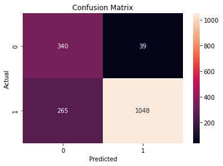

```python
#Confusion Matrix on each model being tested for error analysis
cm=confusion_matrix(yt_test, score)
cm
import seaborn as sns
import matplotlib.pyplot as plt

ax= plt.subplot()
sns.heatmap(cm, annot=True, fmt='g', ax=ax);

ax.set_xlabel('Predicted');ax.set_ylabel('Actual');
ax.set_title('Confusion Matrix');
TN, FP, FN, TP = confusion_matrix(yt_test, score).ravel()

print('True Positive(TP)  = ', TP)
print('False Positive(FP) = ', FP)
print('True Negative(TN)  = ', TN)
print('False Negative(FN) = ', FN)

accuracy = (TP+TN) /(TP+FP+TN+FN)
print('Accuracy of the binary classification = {:0.3f}'.format(accuracy))
```

To see if different models erroneously categorize the same sentences, we generated a dataframe containing predictions for both models and showed it together using the html style tag.

```python
df_DT = pd.DataFrame(score)
df_DT.columns = ["Decision Tree"]
df_DT
```

|  | Decision Tree |
| --- | --- |
| 0 | 1.0 |
| 1 | 1.0 |
| 2 | 0.0 |
| 3 | 1.0 |
| 4 | 1.0 |
| ... | ... |
| 1687 | 1.0 |
| 1688 | 1.0 |
| 1689 | 1.0 |
| 1690 | 1.0 |
| 1691 | 0.0 |

1692 rows × 1 columns

```python
yt_test.dtypes
```

```
dtype('float64')
```

Running Random Forest Classifier

```python
import pickle
from pickle import dump
model_rfc = RandomForestClassifier()
model_rfc.fit(xt_train, yt_train)
dump(model_rfc, open('rfcmodel.pkl', 'wb'))
```

```python
model_rfc = pickle.load(open('rfcmodel.pkl', 'rb'))
```

```python
score = model_rfc.predict(xt_test)
result = accuracy_score(yt_test,score)
print('Test Accuracy:', result)
```

```
Test Accuracy: 0.9190307328605201
```

```
True Positive(TP)  =  1281
False Positive(FP) =  105
True Negative(TN)  =  274
False Negative(FN) =  32
Accuracy of the binary classification = 0.919
```

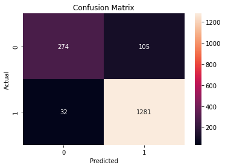

```python
cm=confusion_matrix(yt_test, score)
cm
import seaborn as sns
import matplotlib.pyplot as plt

ax= plt.subplot()
sns.heatmap(cm, annot=True, fmt='g', ax=ax);

# labels, title and ticks
ax.set_xlabel('Predicted');ax.set_ylabel('Actual');
ax.set_title('Confusion Matrix');
TN, FP, FN, TP = confusion_matrix(yt_test, score).ravel()

print('True Positive(TP)  = ', TP)
print('False Positive(FP) = ', FP)
print('True Negative(TN)  = ', TN)
print('False Negative(FN) = ', FN)

accuracy =  (TP+TN) /(TP+FP+TN+FN)

print('Accuracy of the binary classification = {:0.3f}'.format(accuracy))
#ax.xaxis.set_ticklabels(['<=50K', '>50K']); ax.yaxis.set_ticklabels(['<=50K','>50K' ]);
```

```python
df_RF = pd.DataFrame(score)
df_RF.columns = ["Random Forest"]
df_RF
```

|  | Random Forest |
| --- | --- |
| 0 | 1.0 |
| 1 | 1.0 |
| 2 | 1.0 |
| 3 | 1.0 |
| 4 | 1.0 |
| ... | ... |
| 1687 | 1.0 |
| 1688 | 1.0 |
| 1689 | 1.0 |
| 1690 | 1.0 |
| 1691 | 0.0 |

1692 rows × 1 columns

Merging dataframes to show both the Decision Tree and Random Forest Classifier predictions for each text.

Source : [Softhints](https://softhints.com/display-two-pandas-dataframes-side-by-side-jupyter-notebook/)

```python
import pandas as pd
from IPython.display import display_html

df_DT_styler = df_DT.style.set_table_attributes("style='display:inline'").set_caption('df_DT')
df_RF_styler = df_RF.style.set_table_attributes("style='display:inline'").set_caption('df_RF')
#df_LR_styler = df_LR.style.set_table_attributes("style='display:inline'").set_caption('df_LR')

display_html(df_DT_styler._repr_html_()+df_RF_styler._repr_html_(), raw=True)
```

df_DT

|  | Decision Tree |
| --- | --- |
| 0 | 1.000000 |
| 1 | 1.000000 |
| 2 | 0.000000 |
| 3 | 1.000000 |
| 4 | 1.000000 |
| 5 | 1.000000 |
| 6 | 0.000000 |
| 7 | 1.000000 |
| 8 | 1.000000 |
| 9 | 1.000000 |
| 10 | 1.000000 |
| 11 | 0.000000 |
| 12 | 1.000000 |
| 13 | 0.000000 |
| 14 | 1.000000 |
| 15 | 1.000000 |
| 16 | 1.000000 |
| 17 | 1.000000 |
| 18 | 1.000000 |
| 19 | 1.000000 |
| 20 | 0.000000 |
| 21 | 1.000000 |
| 22 | 1.000000 |
| 23 | 1.000000 |
| 24 | 0.000000 |
| 25 | 1.000000 |
| 26 | 1.000000 |
| 27 | 0.000000 |
| 28 | 0.000000 |
| 29 | 1.000000 |

[output cut: 1662 more lines]

df_RF

|  | Random Forest |
| --- | --- |
| 0 | 1.000000 |
| 1 | 1.000000 |
| 2 | 1.000000 |
| 3 | 1.000000 |
| 4 | 1.000000 |
| 5 | 1.000000 |
| 6 | 0.000000 |
| 7 | 1.000000 |
| 8 | 1.000000 |
| 9 | 1.000000 |
| 10 | 1.000000 |
| 11 | 0.000000 |
| 12 | 1.000000 |
| 13 | 0.000000 |
| 14 | 1.000000 |
| 15 | 1.000000 |
| 16 | 1.000000 |
| 17 | 1.000000 |
| 18 | 1.000000 |
| 19 | 1.000000 |
| 20 | 0.000000 |
| 21 | 1.000000 |
| 22 | 1.000000 |
| 23 | 1.000000 |
| 24 | 1.000000 |
| 25 | 1.000000 |
| 26 | 1.000000 |
| 27 | 0.000000 |
| 28 | 1.000000 |
| 29 | 1.000000 |

[output cut: 1662 more lines]

```python
#load valid data
validdata = pd.read_csv("valid.csv",header=0)
validdata
```

|  | headline | authors | link | short_description | date | news_length | category_id |
| --- | --- | --- | --- | --- | --- | --- | --- |
| 0 | 5 of the Most Uber-Luxurious Suites in Las Vegas | Oyster.com, Contributor\nThe Hotel Tell-All | https://www.huffingtonpost.com/entry/5-of-the-... | Vegas is a city that is decidedly over-the-top... | 2013-07-09 | 48.0 | 1.0 |
| 1 | Top 10 Travel Destinations For 2013 | Fly.com, Contributor\nFly.com | https://www.huffingtonpost.com/entry/top-10-tr... | Fly.com recently asked 875 U.S. travelers wher... | 2013-01-08 | 35.0 | 1.0 |
| 2 | Bruges is Beyond Beautiful | Lev Raphael, Contributor\nAuthor, Reviewer, Bl... | https://www.huffingtonpost.com/entry/bruges-is... | Bruges this past month was perfect for the kin... | 2013-05-15 | 26.0 | 1.0 |
| 3 | How Not to Be an Obnoxious Tourist With an Int... | Ben Colclough, Contributor\nAdventure travel e... | https://www.huffingtonpost.com/entry/obnoxious... | Do you ever take photographs of locals when yo... | 2013-04-03 | 59.0 | 1.0 |
| 4 | Expert Answers To 10 Common Travel Questions | SmarterTravel, Contributor\nSmartertravel.com | https://www.huffingtonpost.com/entry/expert-an... | Should you wait to book? How do you spot a goo... | 2012-12-20 | 44.0 | 1.0 |
| ... | ... | ... | ... | ... | ... | ... | ... |
| 1533 | Lonely Planet's Top U.S. Destination Of 2018 I... | Abigail Williams | https://www.huffingtonpost.com/entry/top-desti... | Pack your bags! | 2018-02-06 | 70.0 | 1.0 |
| 1534 | Outrageously Lavish Hotel Suites | Conde Nast Traveler, Contributor\nConde Nast T... | https://www.huffingtonpost.com/entry/outrageou... | By Christian L. Wright, CondÃ© Nast Traveler M... | 2013-09-24 | 32.0 | 1.0 |
| 1535 | Notes From Nicaragua: Listo or Not | Joe Hutcheson, Contributor\nWriter, teacher, s... | https://www.huffingtonpost.com/entry/notes-fro... | Certainly the thought of zip-lining through th... | 2014-02-18 | 34.0 | 1.0 |
| 1536 | Guide To Willamette Valley Wine Country (PHOTOS) | Snooth, Contributor\nSnooth, the world's most ... | https://www.huffingtonpost.com/entry/guide-to-... | The northern portion of Oregon's Willamette Va... | 2012-09-13 | 48.0 | 1.0 |
| 1537 | Bernie Sanders Embodies Trend Of The 'Spiritua... | Antonia Blumberg | https://www.huffingtonpost.com/entry/bernie-sa... | Jane Sanders, the senator's wife, opened up ab... | 2016-02-11 | 75.0 | 0.0 |

1538 rows × 7 columns

Loading Validation Dataset

```python
#data preprocessing
#converting the data to lowercase
validdata = validdata.apply(lambda x: x.astype(str).str.lower())
```

```python
validdata
```

|  | headline | authors | link | short_description | date | news_length | category_id |
| --- | --- | --- | --- | --- | --- | --- | --- |
| 0 | 5 of the most uber-luxurious suites in las vegas | oyster.com, contributor\nthe hotel tell-all | https://www.huffingtonpost.com/entry/5-of-the-... | vegas is a city that is decidedly over-the-top... | 2013-07-09 | 48.0 | 1.0 |
| 1 | top 10 travel destinations for 2013 | fly.com, contributor\nfly.com | https://www.huffingtonpost.com/entry/top-10-tr... | fly.com recently asked 875 u.s. travelers wher... | 2013-01-08 | 35.0 | 1.0 |
| 2 | bruges is beyond beautiful | lev raphael, contributor\nauthor, reviewer, bl... | https://www.huffingtonpost.com/entry/bruges-is... | bruges this past month was perfect for the kin... | 2013-05-15 | 26.0 | 1.0 |
| 3 | how not to be an obnoxious tourist with an int... | ben colclough, contributor\nadventure travel e... | https://www.huffingtonpost.com/entry/obnoxious... | do you ever take photographs of locals when yo... | 2013-04-03 | 59.0 | 1.0 |
| 4 | expert answers to 10 common travel questions | smartertravel, contributor\nsmartertravel.com | https://www.huffingtonpost.com/entry/expert-an... | should you wait to book? how do you spot a goo... | 2012-12-20 | 44.0 | 1.0 |
| ... | ... | ... | ... | ... | ... | ... | ... |
| 1533 | lonely planet's top u.s. destination of 2018 i... | abigail williams | https://www.huffingtonpost.com/entry/top-desti... | pack your bags! | 2018-02-06 | 70.0 | 1.0 |
| 1534 | outrageously lavish hotel suites | conde nast traveler, contributor\nconde nast t... | https://www.huffingtonpost.com/entry/outrageou... | by christian l. wright, condã© nast traveler m... | 2013-09-24 | 32.0 | 1.0 |
| 1535 | notes from nicaragua: listo or not | joe hutcheson, contributor\nwriter, teacher, s... | https://www.huffingtonpost.com/entry/notes-fro... | certainly the thought of zip-lining through th... | 2014-02-18 | 34.0 | 1.0 |
| 1536 | guide to willamette valley wine country (photos) | snooth, contributor\nsnooth, the world's most ... | https://www.huffingtonpost.com/entry/guide-to-... | the northern portion of oregon's willamette va... | 2012-09-13 | 48.0 | 1.0 |
| 1537 | bernie sanders embodies trend of the 'spiritua... | antonia blumberg | https://www.huffingtonpost.com/entry/bernie-sa... | jane sanders, the senator's wife, opened up ab... | 2016-02-11 | 75.0 | 0.0 |

1538 rows × 7 columns

```python
#Removing punctuations from the data
validdata["headline"] = validdata['headline'].str.replace('[^\w\s]','')
validdata
```

|  | headline | authors | link | short_description | date | news_length | category_id |
| --- | --- | --- | --- | --- | --- | --- | --- |
| 0 | 5 of the most uberluxurious suites in las vegas | oyster.com, contributor\nthe hotel tell-all | https://www.huffingtonpost.com/entry/5-of-the-... | vegas is a city that is decidedly over-the-top... | 2013-07-09 | 48.0 | 1.0 |
| 1 | top 10 travel destinations for 2013 | fly.com, contributor\nfly.com | https://www.huffingtonpost.com/entry/top-10-tr... | fly.com recently asked 875 u.s. travelers wher... | 2013-01-08 | 35.0 | 1.0 |
| 2 | bruges is beyond beautiful | lev raphael, contributor\nauthor, reviewer, bl... | https://www.huffingtonpost.com/entry/bruges-is... | bruges this past month was perfect for the kin... | 2013-05-15 | 26.0 | 1.0 |
| 3 | how not to be an obnoxious tourist with an int... | ben colclough, contributor\nadventure travel e... | https://www.huffingtonpost.com/entry/obnoxious... | do you ever take photographs of locals when yo... | 2013-04-03 | 59.0 | 1.0 |
| 4 | expert answers to 10 common travel questions | smartertravel, contributor\nsmartertravel.com | https://www.huffingtonpost.com/entry/expert-an... | should you wait to book? how do you spot a goo... | 2012-12-20 | 44.0 | 1.0 |
| ... | ... | ... | ... | ... | ... | ... | ... |
| 1533 | lonely planets top us destination of 2018 is a... | abigail williams | https://www.huffingtonpost.com/entry/top-desti... | pack your bags! | 2018-02-06 | 70.0 | 1.0 |
| 1534 | outrageously lavish hotel suites | conde nast traveler, contributor\nconde nast t... | https://www.huffingtonpost.com/entry/outrageou... | by christian l. wright, condã© nast traveler m... | 2013-09-24 | 32.0 | 1.0 |
| 1535 | notes from nicaragua listo or not | joe hutcheson, contributor\nwriter, teacher, s... | https://www.huffingtonpost.com/entry/notes-fro... | certainly the thought of zip-lining through th... | 2014-02-18 | 34.0 | 1.0 |
| 1536 | guide to willamette valley wine country photos | snooth, contributor\nsnooth, the world's most ... | https://www.huffingtonpost.com/entry/guide-to-... | the northern portion of oregon's willamette va... | 2012-09-13 | 48.0 | 1.0 |
| 1537 | bernie sanders embodies trend of the spiritual... | antonia blumberg | https://www.huffingtonpost.com/entry/bernie-sa... | jane sanders, the senator's wife, opened up ab... | 2016-02-11 | 75.0 | 0.0 |

1538 rows × 7 columns

```python
#https://www.datasnips.com/58/remove-stop-words-from-text-in-dataframe-column/
from nltk.corpus import stopwords
stop_words = stopwords.words('english')
```

```python
validdata['headline'] = validdata['headline'].apply(lambda x: ' '.join([word for word in str(x).split() if word not in (stop_words)]))
```

```python
validdata
```

|  | headline | authors | link | short_description | date | news_length | category_id |
| --- | --- | --- | --- | --- | --- | --- | --- |
| 0 | 5 uberluxurious suites las vegas | oyster.com, contributor\nthe hotel tell-all | https://www.huffingtonpost.com/entry/5-of-the-... | vegas is a city that is decidedly over-the-top... | 2013-07-09 | 48.0 | 1.0 |
| 1 | top 10 travel destinations 2013 | fly.com, contributor\nfly.com | https://www.huffingtonpost.com/entry/top-10-tr... | fly.com recently asked 875 u.s. travelers wher... | 2013-01-08 | 35.0 | 1.0 |
| 2 | bruges beyond beautiful | lev raphael, contributor\nauthor, reviewer, bl... | https://www.huffingtonpost.com/entry/bruges-is... | bruges this past month was perfect for the kin... | 2013-05-15 | 26.0 | 1.0 |
| 3 | obnoxious tourist intrusive camera | ben colclough, contributor\nadventure travel e... | https://www.huffingtonpost.com/entry/obnoxious... | do you ever take photographs of locals when yo... | 2013-04-03 | 59.0 | 1.0 |
| 4 | expert answers 10 common travel questions | smartertravel, contributor\nsmartertravel.com | https://www.huffingtonpost.com/entry/expert-an... | should you wait to book? how do you spot a goo... | 2012-12-20 | 44.0 | 1.0 |
| ... | ... | ... | ... | ... | ... | ... | ... |
| 1533 | lonely planets top us destination 2018 underra... | abigail williams | https://www.huffingtonpost.com/entry/top-desti... | pack your bags! | 2018-02-06 | 70.0 | 1.0 |
| 1534 | outrageously lavish hotel suites | conde nast traveler, contributor\nconde nast t... | https://www.huffingtonpost.com/entry/outrageou... | by christian l. wright, condã© nast traveler m... | 2013-09-24 | 32.0 | 1.0 |
| 1535 | notes nicaragua listo | joe hutcheson, contributor\nwriter, teacher, s... | https://www.huffingtonpost.com/entry/notes-fro... | certainly the thought of zip-lining through th... | 2014-02-18 | 34.0 | 1.0 |
| 1536 | guide willamette valley wine country photos | snooth, contributor\nsnooth, the world's most ... | https://www.huffingtonpost.com/entry/guide-to-... | the northern portion of oregon's willamette va... | 2012-09-13 | 48.0 | 1.0 |
| 1537 | bernie sanders embodies trend spiritual religi... | antonia blumberg | https://www.huffingtonpost.com/entry/bernie-sa... | jane sanders, the senator's wife, opened up ab... | 2016-02-11 | 75.0 | 0.0 |

1538 rows × 7 columns

```python
#dropping all other columns except Headline as we did for Train Dataset
validdata.drop('authors', axis=1, inplace=True)
validdata.drop('date', axis=1, inplace=True)
validdata.drop('link', axis=1, inplace=True)
validdata.drop('short_description', axis=1, inplace=True)
validdata.drop('news_length', axis=1, inplace=True)
```

```python
validdata['category_id'] = validdata['category_id'].astype(float)
```

```python
validdata
```

|  | headline | category_id |
| --- | --- | --- |
| 0 | 5 uberluxurious suites las vegas | 1.0 |
| 1 | top 10 travel destinations 2013 | 1.0 |
| 2 | bruges beyond beautiful | 1.0 |
| 3 | obnoxious tourist intrusive camera | 1.0 |
| 4 | expert answers 10 common travel questions | 1.0 |
| ... | ... | ... |
| 1533 | lonely planets top us destination 2018 underra... | 1.0 |
| 1534 | outrageously lavish hotel suites | 1.0 |
| 1535 | notes nicaragua listo | 1.0 |
| 1536 | guide willamette valley wine country photos | 1.0 |
| 1537 | bernie sanders embodies trend spiritual religi... | 0.0 |

1538 rows × 2 columns

```python
validdata.count()
```

```
headline       1538
category_id    1538
dtype: int64
```

```python
tfidf_vect = TfidfVectorizer(analyzer='word',max_features=3000)

xv_tfidf = tfidf_vect.fit_transform(validdata['headline'])

xv_features = pd.DataFrame(xv_tfidf.toarray())
```

```python
# splitting the validation dataset to training and testing data
xv_train, xv_test, yv_train, yv_test = train_test_split(xv_features, validdata['category_id'], test_size=0.5)
```

```python
yv_test.dtypes
```

```
dtype('float64')
```

```python
validdata['category_id']
```

```
0       1.0
1       1.0
2       1.0
3       1.0
4       1.0
       ...
1533    1.0
1534    1.0
1535    1.0
1536    1.0
1537    0.0
Name: category_id, Length: 1538, dtype: float64
```

```python
xv_train
```

|  | 0 | 1 | 2 | 3 | 4 | 5 | 6 | 7 | 8 | 9 | ... | 2990 | 2991 | 2992 | 2993 | 2994 | 2995 | 2996 | 2997 | 2998 | 2999 |
| --- | --- | --- | --- | --- | --- | --- | --- | --- | --- | --- | --- | --- | --- | --- | --- | --- | --- | --- | --- | --- | --- |
| 1408 | 0.0 | 0.000000 | 0.0 | 0.0 | 0.0 | 0.0 | 0.0 | 0.0 | 0.0 | 0.0 | ... | 0.0 | 0.0 | 0.0 | 0.0 | 0.0 | 0.0 | 0.0 | 0.0 | 0.0 | 0.0 |
| 866 | 0.0 | 0.000000 | 0.0 | 0.0 | 0.0 | 0.0 | 0.0 | 0.0 | 0.0 | 0.0 | ... | 0.0 | 0.0 | 0.0 | 0.0 | 0.0 | 0.0 | 0.0 | 0.0 | 0.0 | 0.0 |
| 1203 | 0.0 | 0.000000 | 0.0 | 0.0 | 0.0 | 0.0 | 0.0 | 0.0 | 0.0 | 0.0 | ... | 0.0 | 0.0 | 0.0 | 0.0 | 0.0 | 0.0 | 0.0 | 0.0 | 0.0 | 0.0 |
| 22 | 0.0 | 0.000000 | 0.0 | 0.0 | 0.0 | 0.0 | 0.0 | 0.0 | 0.0 | 0.0 | ... | 0.0 | 0.0 | 0.0 | 0.0 | 0.0 | 0.0 | 0.0 | 0.0 | 0.0 | 0.0 |
| 774 | 0.0 | 0.000000 | 0.0 | 0.0 | 0.0 | 0.0 | 0.0 | 0.0 | 0.0 | 0.0 | ... | 0.0 | 0.0 | 0.0 | 0.0 | 0.0 | 0.0 | 0.0 | 0.0 | 0.0 | 0.0 |
| ... | ... | ... | ... | ... | ... | ... | ... | ... | ... | ... | ... | ... | ... | ... | ... | ... | ... | ... | ... | ... | ... |
| 1458 | 0.0 | 0.000000 | 0.0 | 0.0 | 0.0 | 0.0 | 0.0 | 0.0 | 0.0 | 0.0 | ... | 0.0 | 0.0 | 0.0 | 0.0 | 0.0 | 0.0 | 0.0 | 0.0 | 0.0 | 0.0 |
| 1317 | 0.0 | 0.276765 | 0.0 | 0.0 | 0.0 | 0.0 | 0.0 | 0.0 | 0.0 | 0.0 | ... | 0.0 | 0.0 | 0.0 | 0.0 | 0.0 | 0.0 | 0.0 | 0.0 | 0.0 | 0.0 |
| 308 | 0.0 | 0.000000 | 0.0 | 0.0 | 0.0 | 0.0 | 0.0 | 0.0 | 0.0 | 0.0 | ... | 0.0 | 0.0 | 0.0 | 0.0 | 0.0 | 0.0 | 0.0 | 0.0 | 0.0 | 0.0 |
| 908 | 0.0 | 0.000000 | 0.0 | 0.0 | 0.0 | 0.0 | 0.0 | 0.0 | 0.0 | 0.0 | ... | 0.0 | 0.0 | 0.0 | 0.0 | 0.0 | 0.0 | 0.0 | 0.0 | 0.0 | 0.0 |
| 332 | 0.0 | 0.000000 | 0.0 | 0.0 | 0.0 | 0.0 | 0.0 | 0.0 | 0.0 | 0.0 | ... | 0.0 | 0.0 | 0.0 | 0.0 | 0.0 | 0.0 | 0.0 | 0.0 | 0.0 | 0.0 |

769 rows × 3000 columns

```python
model_dtc = DecisionTreeClassifier(max_depth=500)
model_dtc.fit(xv_train, yv_train)
dump(model_dtc, open('dtcmodel.pkl', 'wb'))
```

```python
model_dtc = pickle.load(open('dtcmodel.pkl', 'rb'))
```

```python
score = model_dtc.predict(xv_test)
result = accuracy_score(yv_test,score)
print('Test Accuracy:', result)
```

```
Test Accuracy: 0.8764629388816645
```

```
True Positive(TP)  =  589
False Positive(FP) =  75
True Negative(TN)  =  85
False Negative(FN) =  20
Accuracy of the binary classification = 0.876
```

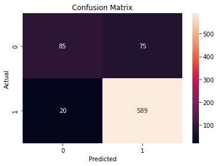

```python
cm=confusion_matrix(yv_test, score) #you will need to change the latter to your desired output
cm
import seaborn as sns
import matplotlib.pyplot as plt

ax= plt.subplot()
sns.heatmap(cm, annot=True, fmt='g', ax=ax);  #Don't worry too much about the arguments here - we will return to this!

# labels, title and ticks
ax.set_xlabel('Predicted');ax.set_ylabel('Actual');
ax.set_title('Confusion Matrix');
TN, FP, FN, TP = confusion_matrix(yv_test, score).ravel()

print('True Positive(TP)  = ', TP)
print('False Positive(FP) = ', FP)
print('True Negative(TN)  = ', TN)
print('False Negative(FN) = ', FN)

accuracy =  (TP+TN) /(TP+FP+TN+FN)

print('Accuracy of the binary classification = {:0.3f}'.format(accuracy))
#ax.xaxis.set_ticklabels(['<=50K', '>50K']); ax.yaxis.set_ticklabels(['<=50K','>50K' ]);
```

```python
df_DTv = pd.DataFrame(score)
df_DTv.columns = ["Decision Tree"]
df_DTv
```

|  | Decision Tree |
| --- | --- |
| 0 | 1.0 |
| 1 | 1.0 |
| 2 | 1.0 |
| 3 | 1.0 |
| 4 | 1.0 |
| ... | ... |
| 764 | 1.0 |
| 765 | 1.0 |
| 766 | 1.0 |
| 767 | 0.0 |
| 768 | 1.0 |

769 rows × 1 columns

```python
model_rfc = RandomForestClassifier()
model_rfc.fit(xv_train, yv_train)
dump(model_rfc, open('rfcmodel.pkl', 'wb'))
```

```python
model_rfc = pickle.load(open('rfcmodel.pkl', 'rb'))
```

```python
score = model_rfc.predict(xv_test)
result = accuracy_score(yv_test,score)
print('Test Accuracy:', result)
```

```
Test Accuracy: 0.8842652795838751
```

```
True Positive(TP)  =  608
False Positive(FP) =  88
True Negative(TN)  =  72
False Negative(FN) =  1
Accuracy of the binary classification = 0.884
```

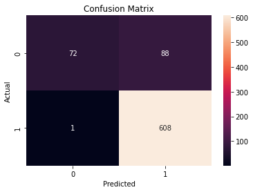

```python
cm=confusion_matrix(yv_test, score) #you will need to change the latter to your desired output
cm
import seaborn as sns
import matplotlib.pyplot as plt

ax= plt.subplot()
sns.heatmap(cm, annot=True, fmt='g', ax=ax);  #Don't worry too much about the arguments here - we will return to this!

# labels, title and ticks
ax.set_xlabel('Predicted');ax.set_ylabel('Actual');
ax.set_title('Confusion Matrix');
TN, FP, FN, TP = confusion_matrix(yv_test, score).ravel()

print('True Positive(TP)  = ', TP)
print('False Positive(FP) = ', FP)
print('True Negative(TN)  = ', TN)
print('False Negative(FN) = ', FN)

accuracy =  (TP+TN) /(TP+FP+TN+FN)

print('Accuracy of the binary classification = {:0.3f}'.format(accuracy))
#ax.xaxis.set_ticklabels(['<=50K', '>50K']); ax.yaxis.set_ticklabels(['<=50K','>50K' ]);
```

```python
df_RFv = pd.DataFrame(score)
df_RFv.columns = ["Random Forest"]
df_RFv
```

|  | Random Forest |
| --- | --- |
| 0 | 1.0 |
| 1 | 1.0 |
| 2 | 1.0 |
| 3 | 1.0 |
| 4 | 1.0 |
| ... | ... |
| 764 | 1.0 |
| 765 | 1.0 |
| 766 | 1.0 |
| 767 | 0.0 |
| 768 | 1.0 |

769 rows × 1 columns

```python
#Merging dataframes
#https://softhints.com/display-two-pandas-dataframes-side-by-side-jupyter-notebook/
import pandas as pd
from IPython.display import display_html


df_DTv_styler = df_DT.style.set_table_attributes("style='display:inline'").set_caption('df_DTv')
df_RFv_styler = df_RF.style.set_table_attributes("style='display:inline'").set_caption('df_RFv')
#df_LRv_styler = df_LR.style.set_table_attributes("style='display:inline'").set_caption('df_LRv')


display_html(df_DTv_styler._repr_html_()+df_RFv_styler._repr_html_(), raw=True)
```

df_DTv

|  | Decision Tree |
| --- | --- |
| 0 | 1.000000 |
| 1 | 1.000000 |
| 2 | 0.000000 |
| 3 | 1.000000 |
| 4 | 1.000000 |
| 5 | 1.000000 |
| 6 | 0.000000 |
| 7 | 1.000000 |
| 8 | 1.000000 |
| 9 | 1.000000 |
| 10 | 1.000000 |
| 11 | 0.000000 |
| 12 | 1.000000 |
| 13 | 0.000000 |
| 14 | 1.000000 |
| 15 | 1.000000 |
| 16 | 1.000000 |
| 17 | 1.000000 |
| 18 | 1.000000 |
| 19 | 1.000000 |
| 20 | 0.000000 |
| 21 | 1.000000 |
| 22 | 1.000000 |
| 23 | 1.000000 |
| 24 | 0.000000 |
| 25 | 1.000000 |
| 26 | 1.000000 |
| 27 | 0.000000 |
| 28 | 0.000000 |
| 29 | 1.000000 |

[output cut: 1662 more lines]

df_RFv

|  | Random Forest |
| --- | --- |
| 0 | 1.000000 |
| 1 | 1.000000 |
| 2 | 1.000000 |
| 3 | 1.000000 |
| 4 | 1.000000 |
| 5 | 1.000000 |
| 6 | 0.000000 |
| 7 | 1.000000 |
| 8 | 1.000000 |
| 9 | 1.000000 |
| 10 | 1.000000 |
| 11 | 0.000000 |
| 12 | 1.000000 |
| 13 | 0.000000 |
| 14 | 1.000000 |
| 15 | 1.000000 |
| 16 | 1.000000 |
| 17 | 1.000000 |
| 18 | 1.000000 |
| 19 | 1.000000 |
| 20 | 0.000000 |
| 21 | 1.000000 |
| 22 | 1.000000 |
| 23 | 1.000000 |
| 24 | 1.000000 |
| 25 | 1.000000 |
| 26 | 1.000000 |
| 27 | 0.000000 |
| 28 | 1.000000 |
| 29 | 1.000000 |

[output cut: 1662 more lines]

Evaluating performance of each model on both train and validation dataset:

"Random forest is preferred over decision tree because decision trees are prone to overfitting, especially when a tree is exceptionally deep, while random forest has the capacity to restrict overfitting without significantly increasing error due to bias. Other advantages of the random forest classifier include its ability to run efficiently on huge datasets and provide higher accuracy than other classification methods."

### Applying one modification to the Train Dataset, specifically adding one more step and performing Lemmatization

```python
traindata['headline'] = traindata['headline'] .str.lower()
```

```python
traindata['headline'] = traindata['headline'].str.replace(r'[^\w\s]+','')
```

```python
import nltk
from nltk.corpus import stopwords
stop = stopwords.words('english')
```

```python
traindata['headline'] = traindata['headline'].apply(lambda x: ' '.join([word for word in str(x).split() if word not in (stop)]))
```

```python
import nltk
nltk.download('omw-1.4')
```

```
True
```

**Performing lemmatization on the data as it provides better results by performing an analysis that depends on the word's part-of-speech and producing real, dictionary words.**

```python
lemmatizer = nltk.stem.WordNetLemmatizer()
traindata['headline'] = [lemmatizer.lemmatize(t) for t in traindata['headline']]
```

```python
traindata['headline']
```

```
0       seaworld unveiled new plan win back visitors r...
1                             nightlife marrakesh morocco
2                                  time vigilance ukraine
3                               never lose luggage 4 tips
4       rep keith ellison optimistic americans overcom...
                              ...
3378        7 fashionable hotels around world every style
3379            7 reasons next vacation charleston suburb
3380    tourists comedy gets stonecold british guard c...
3381                  government shutdown means travelers
3382                                travel taught reality
Name: headline, Length: 3383, dtype: object
```

```python
tfidf_vect = TfidfVectorizer(analyzer='word',max_features=3000)

xt_tfidf = tfidf_vect.fit_transform(traindata['headline'])

xt_features = pd.DataFrame(xt_tfidf.toarray())
```

```python
x_train2, x_test2, y_train2, y_test2 = train_test_split(xt_features, traindata['category_id'], test_size=0.5)
```

```python
x_train2
```

|  | 0 | 1 | 2 | 3 | 4 | 5 | 6 | 7 | 8 | 9 | ... | 2990 | 2991 | 2992 | 2993 | 2994 | 2995 | 2996 | 2997 | 2998 | 2999 |
| --- | --- | --- | --- | --- | --- | --- | --- | --- | --- | --- | --- | --- | --- | --- | --- | --- | --- | --- | --- | --- | --- |
| 1617 | 0.0 | 0.0 | 0.0 | 0.0 | 0.0 | 0.0 | 0.0 | 0.0 | 0.0 | 0.0 | ... | 0.0 | 0.0 | 0.0 | 0.0 | 0.0 | 0.0 | 0.0 | 0.0 | 0.0 | 0.0 |
| 1207 | 0.0 | 0.0 | 0.0 | 0.0 | 0.0 | 0.0 | 0.0 | 0.0 | 0.0 | 0.0 | ... | 0.0 | 0.0 | 0.0 | 0.0 | 0.0 | 0.0 | 0.0 | 0.0 | 0.0 | 0.0 |
| 2163 | 0.0 | 0.0 | 0.0 | 0.0 | 0.0 | 0.0 | 0.0 | 0.0 | 0.0 | 0.0 | ... | 0.0 | 0.0 | 0.0 | 0.0 | 0.0 | 0.0 | 0.0 | 0.0 | 0.0 | 0.0 |
| 2870 | 0.0 | 0.0 | 0.0 | 0.0 | 0.0 | 0.0 | 0.0 | 0.0 | 0.0 | 0.0 | ... | 0.0 | 0.0 | 0.0 | 0.0 | 0.0 | 0.0 | 0.0 | 0.0 | 0.0 | 0.0 |
| 226 | 0.0 | 0.0 | 0.0 | 0.0 | 0.0 | 0.0 | 0.0 | 0.0 | 0.0 | 0.0 | ... | 0.0 | 0.0 | 0.0 | 0.0 | 0.0 | 0.0 | 0.0 | 0.0 | 0.0 | 0.0 |
| ... | ... | ... | ... | ... | ... | ... | ... | ... | ... | ... | ... | ... | ... | ... | ... | ... | ... | ... | ... | ... | ... |
| 614 | 0.0 | 0.0 | 0.0 | 0.0 | 0.0 | 0.0 | 0.0 | 0.0 | 0.0 | 0.0 | ... | 0.0 | 0.0 | 0.0 | 0.0 | 0.0 | 0.0 | 0.0 | 0.0 | 0.0 | 0.0 |
| 2925 | 0.0 | 0.0 | 0.0 | 0.0 | 0.0 | 0.0 | 0.0 | 0.0 | 0.0 | 0.0 | ... | 0.0 | 0.0 | 0.0 | 0.0 | 0.0 | 0.0 | 0.0 | 0.0 | 0.0 | 0.0 |
| 65 | 0.0 | 0.0 | 0.0 | 0.0 | 0.0 | 0.0 | 0.0 | 0.0 | 0.0 | 0.0 | ... | 0.0 | 0.0 | 0.0 | 0.0 | 0.0 | 0.0 | 0.0 | 0.0 | 0.0 | 0.0 |
| 1833 | 0.0 | 0.0 | 0.0 | 0.0 | 0.0 | 0.0 | 0.0 | 0.0 | 0.0 | 0.0 | ... | 0.0 | 0.0 | 0.0 | 0.0 | 0.0 | 0.0 | 0.0 | 0.0 | 0.0 | 0.0 |
| 830 | 0.0 | 0.0 | 0.0 | 0.0 | 0.0 | 0.0 | 0.0 | 0.0 | 0.0 | 0.0 | ... | 0.0 | 0.0 | 0.0 | 0.0 | 0.0 | 0.0 | 0.0 | 0.0 | 0.0 | 0.0 |

1691 rows × 3000 columns

```python
model_dtct = DecisionTreeClassifier(max_depth=500)
model_dtct.fit(x_train2, y_train2)
dump(model_dtct, open('dtctmodel.pkl', 'wb'))
```

```python
model_dtct = pickle.load(open('dtctmodel.pkl', 'rb'))
```

```python
score = model_dtct.predict(x_test2)
result = accuracy_score(y_test2,score)
print('Test Accuracy:', result)
```

```
Test Accuracy: 0.8764775413711584
```

```
True Positive(TP)  =  1265
False Positive(FP) =  161
True Negative(TN)  =  218
False Negative(FN) =  48
Accuracy of the binary classification = 0.876
```

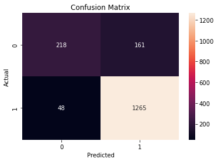

```python
cm=confusion_matrix(y_test2, score) #you will need to change the latter to your desired output
cm
import seaborn as sns
import matplotlib.pyplot as plt

ax= plt.subplot()
sns.heatmap(cm, annot=True, fmt='g', ax=ax);  #Don't worry too much about the arguments here - we will return to this!

# labels, title and ticks
ax.set_xlabel('Predicted');ax.set_ylabel('Actual');
ax.set_title('Confusion Matrix');
TN, FP, FN, TP = confusion_matrix(y_test2, score).ravel()

print('True Positive(TP)  = ', TP)
print('False Positive(FP) = ', FP)
print('True Negative(TN)  = ', TN)
print('False Negative(FN) = ', FN)

accuracy =  (TP+TN) /(TP+FP+TN+FN)

print('Accuracy of the binary classification = {:0.3f}'.format(accuracy))
```

```python
model_rfct = RandomForestClassifier()
model_rfct.fit(x_train2, y_train2)
dump(model_rfct, open('rfctmodel.pkl', 'wb'))
```

```python
model_rfct = pickle.load(open('rfctmodel.pkl', 'rb'))
```

```python
score = model_rfct.predict(x_test2)
result = accuracy_score(y_test2,score)
print('Test Accuracy:', result)
```

```
Test Accuracy: 0.9078014184397163
```

```
True Positive(TP)  =  1293
False Positive(FP) =  136
True Negative(TN)  =  243
False Negative(FN) =  20
Accuracy of the binary classification = 0.908
```

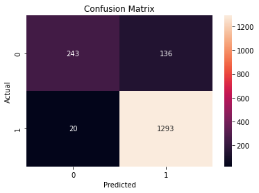

```python
cm=confusion_matrix(y_test2, score) #you will need to change the latter to your desired output
cm
import seaborn as sns
import matplotlib.pyplot as plt

ax= plt.subplot()
sns.heatmap(cm, annot=True, fmt='g', ax=ax);  #Don't worry too much about the arguments here - we will return to this!

# labels, title and ticks
ax.set_xlabel('Predicted');ax.set_ylabel('Actual');
ax.set_title('Confusion Matrix');
TN, FP, FN, TP = confusion_matrix(y_test2, score).ravel()

print('True Positive(TP)  = ', TP)
print('False Positive(FP) = ', FP)
print('True Negative(TN)  = ', TN)
print('False Negative(FN) = ', FN)

accuracy =  (TP+TN) /(TP+FP+TN+FN)

print('Accuracy of the binary classification = {:0.3f}'.format(accuracy))
```

Even after adding one more extra preprocessing step, lemmatization, there was no significant change on the training dataset, since the accuracy for both models was nearly identical to the prior models evaluated without lemmatization.

### Applying one modification to the Validation Dataset, specifically adding one more step and performing Lemmatization

```python
validdata['headline'] = validdata['headline'] .str.lower()
```

```python
validdata['headline'] = validdata['headline'].str.replace(r'[^\w\s]+','')
```

```python
import nltk
from nltk.corpus import stopwords
stop = stopwords.words('english')
```

```python
validdata['headline'] = validdata['headline'].apply(lambda x: ' '.join([word for word in str(x).split() if word not in (stop)]))
```

**Performing lemmatization on the data as it provides better results by performing an analysis that depends on the word's part-of-speech and producing real, dictionary words.**

```python
lemmatizer = nltk.stem.WordNetLemmatizer()
validdata['headline'] = [lemmatizer.lemmatize(t) for t in validdata['headline']]
```

```python
validdata['headline']
```

```
0                        5 uberluxurious suites las vegas
1                         top 10 travel destinations 2013
2                                 bruges beyond beautiful
3                      obnoxious tourist intrusive camera
4               expert answers 10 common travel questions
                              ...
1533    lonely planets top us destination 2018 underra...
1534                     outrageously lavish hotel suites
1535                                notes nicaragua listo
1536          guide willamette valley wine country photos
1537    bernie sanders embodies trend spiritual religi...
Name: headline, Length: 1538, dtype: object
```

```python
tfidf_vect = TfidfVectorizer(analyzer='word', max_features=3000)

xv2_tfidf = tfidf_vect.fit_transform(validdata['headline'])

xv2_features = pd.DataFrame(xv2_tfidf.toarray())
```

```python
xv2_train, xv2_test, yv2_train, yv2_test = train_test_split(xv2_features, validdata['category_id'], test_size=0.5)
```

```python
xv2_train
```

|  | 0 | 1 | 2 | 3 | 4 | 5 | 6 | 7 | 8 | 9 | ... | 2990 | 2991 | 2992 | 2993 | 2994 | 2995 | 2996 | 2997 | 2998 | 2999 |
| --- | --- | --- | --- | --- | --- | --- | --- | --- | --- | --- | --- | --- | --- | --- | --- | --- | --- | --- | --- | --- | --- |
| 42 | 0.0 | 0.0 | 0.0 | 0.0 | 0.0 | 0.0 | 0.0 | 0.0 | 0.0 | 0.0 | ... | 0.0 | 0.0 | 0.0 | 0.0 | 0.0 | 0.0 | 0.0 | 0.0 | 0.000000 | 0.0 |
| 820 | 0.0 | 0.0 | 0.0 | 0.0 | 0.0 | 0.0 | 0.0 | 0.0 | 0.0 | 0.0 | ... | 0.0 | 0.0 | 0.0 | 0.0 | 0.0 | 0.0 | 0.0 | 0.0 | 0.000000 | 0.0 |
| 341 | 0.0 | 0.0 | 0.0 | 0.0 | 0.0 | 0.0 | 0.0 | 0.0 | 0.0 | 0.0 | ... | 0.0 | 0.0 | 0.0 | 0.0 | 0.0 | 0.0 | 0.0 | 0.0 | 0.000000 | 0.0 |
| 460 | 0.0 | 0.0 | 0.0 | 0.0 | 0.0 | 0.0 | 0.0 | 0.0 | 0.0 | 0.0 | ... | 0.0 | 0.0 | 0.0 | 0.0 | 0.0 | 0.0 | 0.0 | 0.0 | 0.000000 | 0.0 |
| 1277 | 0.0 | 0.0 | 0.0 | 0.0 | 0.0 | 0.0 | 0.0 | 0.0 | 0.0 | 0.0 | ... | 0.0 | 0.0 | 0.0 | 0.0 | 0.0 | 0.0 | 0.0 | 0.0 | 0.000000 | 0.0 |
| ... | ... | ... | ... | ... | ... | ... | ... | ... | ... | ... | ... | ... | ... | ... | ... | ... | ... | ... | ... | ... | ... |
| 645 | 0.0 | 0.0 | 0.0 | 0.0 | 0.0 | 0.0 | 0.0 | 0.0 | 0.0 | 0.0 | ... | 0.0 | 0.0 | 0.0 | 0.0 | 0.0 | 0.0 | 0.0 | 0.0 | 0.000000 | 0.0 |
| 1113 | 0.0 | 0.0 | 0.0 | 0.0 | 0.0 | 0.0 | 0.0 | 0.0 | 0.0 | 0.0 | ... | 0.0 | 0.0 | 0.0 | 0.0 | 0.0 | 0.0 | 0.0 | 0.0 | 0.000000 | 0.0 |
| 49 | 0.0 | 0.0 | 0.0 | 0.0 | 0.0 | 0.0 | 0.0 | 0.0 | 0.0 | 0.0 | ... | 0.0 | 0.0 | 0.0 | 0.0 | 0.0 | 0.0 | 0.0 | 0.0 | 0.000000 | 0.0 |
| 1411 | 0.0 | 0.0 | 0.0 | 0.0 | 0.0 | 0.0 | 0.0 | 0.0 | 0.0 | 0.0 | ... | 0.0 | 0.0 | 0.0 | 0.0 | 0.0 | 0.0 | 0.0 | 0.0 | 0.000000 | 0.0 |
| 169 | 0.0 | 0.0 | 0.0 | 0.0 | 0.0 | 0.0 | 0.0 | 0.0 | 0.0 | 0.0 | ... | 0.0 | 0.0 | 0.0 | 0.0 | 0.0 | 0.0 | 0.0 | 0.0 | 0.496659 | 0.0 |

769 rows × 3000 columns

```python
model_dtct = DecisionTreeClassifier(max_depth=500)
model_dtct.fit(xv2_train, yv2_train)
dump(model_dtct, open('dtctmodel.pkl', 'wb'))
```

```python
model_dtct = pickle.load(open('dtctmodel.pkl', 'rb'))
```

```python
score = model_dtct.predict(xv2_test)
result = accuracy_score(yv2_test,score)
print('Test Accuracy:', result)
```

```
Test Accuracy: 0.7373211963589077
```

```
True Positive(TP)  =  433
False Positive(FP) =  29
True Negative(TN)  =  134
False Negative(FN) =  173
Accuracy of the binary classification = 0.737
```

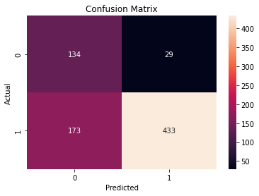

```python
cm=confusion_matrix(yv2_test, score) #you will need to change the latter to your desired output
cm
import seaborn as sns
import matplotlib.pyplot as plt

ax= plt.subplot()
sns.heatmap(cm, annot=True, fmt='g', ax=ax);  #Don't worry too much about the arguments here - we will return to this!

# labels, title and ticks
ax.set_xlabel('Predicted');ax.set_ylabel('Actual');
ax.set_title('Confusion Matrix');
TN, FP, FN, TP = confusion_matrix(yv2_test, score).ravel()

print('True Positive(TP)  = ', TP)
print('False Positive(FP) = ', FP)
print('True Negative(TN)  = ', TN)
print('False Negative(FN) = ', FN)

accuracy =  (TP+TN) /(TP+FP+TN+FN)

print('Accuracy of the binary classification = {:0.3f}'.format(accuracy))
```

```python
model_rfct = RandomForestClassifier()
model_rfct.fit(xv2_train, yv2_train)
dump(model_rfct, open('rfctmodel.pkl', 'wb'))
```

```python
model_rfct = pickle.load(open('rfctmodel.pkl', 'rb'))
```

```python
score = model_rfct.predict(xv2_test)
result = accuracy_score(yv2_test,score)
print('Test Accuracy:', result)
```

```
Test Accuracy: 0.8803641092327699
```

```
True Positive(TP)  =  561
False Positive(FP) =  47
True Negative(TN)  =  116
False Negative(FN) =  45
Accuracy of the binary classification = 0.880
```

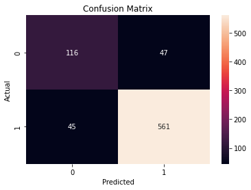

```python
cm=confusion_matrix(yv2_test, score) #you will need to change the latter to your desired output
cm
import seaborn as sns
import matplotlib.pyplot as plt

ax= plt.subplot()
sns.heatmap(cm, annot=True, fmt='g', ax=ax);  #Don't worry too much about the arguments here - we will return to this!

# labels, title and ticks
ax.set_xlabel('Predicted');ax.set_ylabel('Actual');
ax.set_title('Confusion Matrix');
TN, FP, FN, TP = confusion_matrix(yv2_test, score).ravel()

print('True Positive(TP)  = ', TP)
print('False Positive(FP) = ', FP)
print('True Negative(TN)  = ', TN)
print('False Negative(FN) = ', FN)

accuracy =  (TP+TN) /(TP+FP+TN+FN)

print('Accuracy of the binary classification = {:0.3f}'.format(accuracy))
```

After adding lemmatization to the Validation Dataset and running the classifiers, we saw a difference in accuracy, which improved for both the Decision Tree and the Random Forest. We are then saving Random Forest model that will be applied on Test data.

### Cross Validation

Cross Validation helps in finding the optimal value of hyperparameters to increase the efficiency of the algorithm.

Merging training dataset and validation dataset to perform K-Fold cross validation on it.

```python
merged_dfx = pd.concat([X_train, X_valid], axis=0) #merging x train and x valid datasets
```

```python
merged_dfx
```

|  | headline | authors | link | short_description | date | news_length | category_id |
| --- | --- | --- | --- | --- | --- | --- | --- |
| 5486 | SeaWorld Just Unveiled A New Plan To Win Back ... | Suzy Strutner | https://www.huffingtonpost.com/entry/seaworld-... | The "Blackfish Effect" is a lot to overcome. | 2016-09-27 | 85.0 | 1.0 |
| 7474 | The Nightlife In Marrakesh, Morocco | Go Ahead Tours, ContributorOffering 100+ tours... | https://www.huffingtonpost.com/entry/the-night... | Spending a night in Marrakesh will produce exp... | 2015-03-06 | 35.0 | 1.0 |
| 7827 | A Time of Vigilance in the Ukraine | Rabbi Michael Bernstein, ContributorCongregati... | https://www.huffingtonpost.com/entry/a-time-of... | We are challenged these days by the ugly remin... | 2014-04-19 | 34.0 | 0.0 |
| 7540 | Never Lose Your Luggage Again With These 4 Tips | U.S. News Travel, ContributorU.S. News & World... | https://www.huffingtonpost.com/entry/never-los... | If you're stuck at the airport looking at an e... | 2015-05-13 | 47.0 | 1.0 |
| 3399 | Rep. Keith Ellison Is Optimistic About America... | Jared Greenhouse | https://www.huffingtonpost.com/entry/keith-ell... | A recently released Gallup pollÂ showed that 6... | 2015-07-21 | 82.0 | 0.0 |
| ... | ... | ... | ... | ... | ... | ... | ... |
| 2509 | Lonely Planet's Top U.S. Destination Of 2018 I... | Abigail Williams | https://www.huffingtonpost.com/entry/top-desti... | Pack your bags! | 2018-02-06 | 70.0 | 1.0 |
| 4629 | Outrageously Lavish Hotel Suites | Conde Nast Traveler, Contributor\nConde Nast T... | https://www.huffingtonpost.com/entry/outrageou... | By Christian L. Wright, CondÃ© Nast Traveler M... | 2013-09-24 | 32.0 | 1.0 |
| 2555 | Notes From Nicaragua: Listo or Not | Joe Hutcheson, Contributor\nWriter, teacher, s... | https://www.huffingtonpost.com/entry/notes-fro... | Certainly the thought of zip-lining through th... | 2014-02-18 | 34.0 | 1.0 |
| 7846 | Guide To Willamette Valley Wine Country (PHOTOS) | Snooth, Contributor\nSnooth, the world's most ... | https://www.huffingtonpost.com/entry/guide-to-... | The northern portion of Oregon's Willamette Va... | 2012-09-13 | 48.0 | 1.0 |
| 3765 | Bernie Sanders Embodies Trend Of The 'Spiritua... | Antonia Blumberg | https://www.huffingtonpost.com/entry/bernie-sa... | Jane Sanders, the senator's wife, opened up ab... | 2016-02-11 | 75.0 | 0.0 |

4921 rows × 7 columns

```python
merged_dfx.pop('date')
```

```
5486    2016-09-27
7474    2015-03-06
7827    2014-04-19
7540    2015-05-13
3399    2015-07-21
           ...
2509    2018-02-06
4629    2013-09-24
2555    2014-02-18
7846    2012-09-13
3765    2016-02-11
Name: date, Length: 4921, dtype: object
```

```python
merged_dfx.pop('authors')
```

```
5486                                        Suzy Strutner
7474    Go Ahead Tours, ContributorOffering 100+ tours...
7827    Rabbi Michael Bernstein, ContributorCongregati...
7540    U.S. News Travel, ContributorU.S. News & World...
3399                                     Jared Greenhouse
                              ...
2509                                     Abigail Williams
4629    Conde Nast Traveler, Contributor\nConde Nast T...
2555    Joe Hutcheson, Contributor\nWriter, teacher, s...
7846    Snooth, Contributor\nSnooth, the world's most ...
3765                                     Antonia Blumberg
Name: authors, Length: 4921, dtype: object
```

```python
merged_dfx.pop('link')
```

```
5486    https://www.huffingtonpost.com/entry/seaworld-...
7474    https://www.huffingtonpost.com/entry/the-night...
7827    https://www.huffingtonpost.com/entry/a-time-of...
7540    https://www.huffingtonpost.com/entry/never-los...
3399    https://www.huffingtonpost.com/entry/keith-ell...
                              ...
2509    https://www.huffingtonpost.com/entry/top-desti...
4629    https://www.huffingtonpost.com/entry/outrageou...
2555    https://www.huffingtonpost.com/entry/notes-fro...
7846    https://www.huffingtonpost.com/entry/guide-to-...
3765    https://www.huffingtonpost.com/entry/bernie-sa...
Name: link, Length: 4921, dtype: object
```

```python
merged_dfx.pop('short_description')
```

```
5486         The "Blackfish Effect" is a lot to overcome.
7474    Spending a night in Marrakesh will produce exp...
7827    We are challenged these days by the ugly remin...
7540    If you're stuck at the airport looking at an e...
3399    A recently released Gallup pollÂ showed that 6...
                              ...
2509                                      Pack your bags!
4629    By Christian L. Wright, CondÃ© Nast Traveler M...
2555    Certainly the thought of zip-lining through th...
7846    The northern portion of Oregon's Willamette Va...
3765    Jane Sanders, the senator's wife, opened up ab...
Name: short_description, Length: 4921, dtype: object
```

```python
merged_dfx.pop('news_length')
```

```
5486    85.0
7474    35.0
7827    34.0
7540    47.0
3399    82.0
        ...
2509    70.0
4629    32.0
2555    34.0
7846    48.0
3765    75.0
Name: news_length, Length: 4921, dtype: float64
```

```python
merged_dfx.pop('category_id')
```

```
5486    1.0
7474    1.0
7827    0.0
7540    1.0
3399    0.0
       ...
2509    1.0
4629    1.0
2555    1.0
7846    1.0
3765    0.0
Name: category_id, Length: 4921, dtype: float64
```

```python
merged_dfx
```

|  | headline |
| --- | --- |
| 5486 | SeaWorld Just Unveiled A New Plan To Win Back ... |
| 7474 | The Nightlife In Marrakesh, Morocco |
| 7827 | A Time of Vigilance in the Ukraine |
| 7540 | Never Lose Your Luggage Again With These 4 Tips |
| 3399 | Rep. Keith Ellison Is Optimistic About America... |
| ... | ... |
| 2509 | Lonely Planet's Top U.S. Destination Of 2018 I... |
| 4629 | Outrageously Lavish Hotel Suites |
| 2555 | Notes From Nicaragua: Listo or Not |
| 7846 | Guide To Willamette Valley Wine Country (PHOTOS) |
| 3765 | Bernie Sanders Embodies Trend Of The 'Spiritua... |

4921 rows × 1 columns

```python
#converting the data to lowercase
merged_dfx['headline'] = merged_dfx['headline'].str.lower()
merged_dfx
```

|  | headline |
| --- | --- |
| 5486 | seaworld just unveiled a new plan to win back ... |
| 7474 | the nightlife in marrakesh, morocco |
| 7827 | a time of vigilance in the ukraine |
| 7540 | never lose your luggage again with these 4 tips |
| 3399 | rep. keith ellison is optimistic about america... |
| ... | ... |
| 2509 | lonely planet's top u.s. destination of 2018 i... |
| 4629 | outrageously lavish hotel suites |
| 2555 | notes from nicaragua: listo or not |
| 7846 | guide to willamette valley wine country (photos) |
| 3765 | bernie sanders embodies trend of the 'spiritua... |

4921 rows × 1 columns

```python
tfidf_vect = TfidfVectorizer(analyzer='word', max_features=3000)

xdfx_tfidf = tfidf_vect.fit_transform(merged_dfx['headline'])

xdfx_features = pd.DataFrame(xdfx_tfidf.toarray())
```

```python
xdfx_features
```

|  | 0 | 1 | 2 | 3 | 4 | 5 | 6 | 7 | 8 | 9 | ... | 2990 | 2991 | 2992 | 2993 | 2994 | 2995 | 2996 | 2997 | 2998 | 2999 |
| --- | --- | --- | --- | --- | --- | --- | --- | --- | --- | --- | --- | --- | --- | --- | --- | --- | --- | --- | --- | --- | --- |
| 0 | 0.0 | 0.0 | 0.0 | 0.0 | 0.0 | 0.0 | 0.0 | 0.0 | 0.0 | 0.0 | ... | 0.0 | 0.0 | 0.0 | 0.0 | 0.0 | 0.0 | 0.0 | 0.0 | 0.0 | 0.0 |
| 1 | 0.0 | 0.0 | 0.0 | 0.0 | 0.0 | 0.0 | 0.0 | 0.0 | 0.0 | 0.0 | ... | 0.0 | 0.0 | 0.0 | 0.0 | 0.0 | 0.0 | 0.0 | 0.0 | 0.0 | 0.0 |
| 2 | 0.0 | 0.0 | 0.0 | 0.0 | 0.0 | 0.0 | 0.0 | 0.0 | 0.0 | 0.0 | ... | 0.0 | 0.0 | 0.0 | 0.0 | 0.0 | 0.0 | 0.0 | 0.0 | 0.0 | 0.0 |
| 3 | 0.0 | 0.0 | 0.0 | 0.0 | 0.0 | 0.0 | 0.0 | 0.0 | 0.0 | 0.0 | ... | 0.0 | 0.0 | 0.0 | 0.0 | 0.0 | 0.0 | 0.0 | 0.0 | 0.0 | 0.0 |
| 4 | 0.0 | 0.0 | 0.0 | 0.0 | 0.0 | 0.0 | 0.0 | 0.0 | 0.0 | 0.0 | ... | 0.0 | 0.0 | 0.0 | 0.0 | 0.0 | 0.0 | 0.0 | 0.0 | 0.0 | 0.0 |
| ... | ... | ... | ... | ... | ... | ... | ... | ... | ... | ... | ... | ... | ... | ... | ... | ... | ... | ... | ... | ... | ... |
| 4916 | 0.0 | 0.0 | 0.0 | 0.0 | 0.0 | 0.0 | 0.0 | 0.0 | 0.0 | 0.0 | ... | 0.0 | 0.0 | 0.0 | 0.0 | 0.0 | 0.0 | 0.0 | 0.0 | 0.0 | 0.0 |
| 4917 | 0.0 | 0.0 | 0.0 | 0.0 | 0.0 | 0.0 | 0.0 | 0.0 | 0.0 | 0.0 | ... | 0.0 | 0.0 | 0.0 | 0.0 | 0.0 | 0.0 | 0.0 | 0.0 | 0.0 | 0.0 |
| 4918 | 0.0 | 0.0 | 0.0 | 0.0 | 0.0 | 0.0 | 0.0 | 0.0 | 0.0 | 0.0 | ... | 0.0 | 0.0 | 0.0 | 0.0 | 0.0 | 0.0 | 0.0 | 0.0 | 0.0 | 0.0 |
| 4919 | 0.0 | 0.0 | 0.0 | 0.0 | 0.0 | 0.0 | 0.0 | 0.0 | 0.0 | 0.0 | ... | 0.0 | 0.0 | 0.0 | 0.0 | 0.0 | 0.0 | 0.0 | 0.0 | 0.0 | 0.0 |
| 4920 | 0.0 | 0.0 | 0.0 | 0.0 | 0.0 | 0.0 | 0.0 | 0.0 | 0.0 | 0.0 | ... | 0.0 | 0.0 | 0.0 | 0.0 | 0.0 | 0.0 | 0.0 | 0.0 | 0.0 | 0.0 |

4921 rows × 3000 columns

```python
merged_dfy = pd.concat([traindata['category_id'], validdata['category_id']], axis=0) #merging y train and y valid datasets
```

```python
merged_dfy
```

```
0       1.0
1       1.0
2       0.0
3       1.0
4       0.0
       ...
1533    1.0
1534    1.0
1535    1.0
1536    1.0
1537    0.0
Name: category_id, Length: 4921, dtype: float64
```

K-Fold Cross Validation for Decision Tree Classifier

```python
model_dtct = pickle.load(open('dtctmodel.pkl', 'rb'))
#dt = DecisionTreeClassifier()
```

```python
from sklearn.model_selection import KFold
folder = KFold(n_splits=5)
```

```python
from sklearn.model_selection import cross_val_score
results = cross_val_score(model_dtct, xdfx_features, merged_dfy, cv = folder)
results
```

```
array([0.86497462, 0.86178862, 0.85162602, 0.8851626 , 0.84654472])
```

```python
output = pd.DataFrame(results, columns=["Accuracy_per_fold"]) #Accuracy Score for 5 folds
output
```

|  | Accuracy_per_fold |
| --- | --- |
| 0 | 0.864975 |
| 1 | 0.861789 |
| 2 | 0.851626 |
| 3 | 0.885163 |
| 4 | 0.846545 |

```python
# mean of the Accuracy_per_fold column!
av_val = output["Accuracy_per_fold"].mean()*100
print("The average accuracy across folds is {}%".format(av_val))
```

```
The average accuracy across folds is 86.20193141017705%
```

K-Fold Cross Validation for Random Forest Classifier

```python
#rf = RandomForestClassifier()
model_rfct = pickle.load(open('rfctmodel.pkl', 'rb'))
```

```python
from sklearn.model_selection import KFold
folder = KFold(n_splits=5)
```

```python
from sklearn.model_selection import cross_val_score
results = cross_val_score(model_rfct, xdfx_features, merged_dfy, cv = folder)
results
```

```
array([0.89340102, 0.91768293, 0.89126016, 0.90955285, 0.91158537])
```

```python
output = pd.DataFrame(results, columns=["Accuracy_per_fold"])
output
```

|  | Accuracy_per_fold |
| --- | --- |
| 0 | 0.893401 |
| 1 | 0.917683 |
| 2 | 0.891260 |
| 3 | 0.909553 |
| 4 | 0.911585 |

```python
# mean of the column!
av_val = output["Accuracy_per_fold"].mean()*100
print("The average accuracy across folds is {}%".format(av_val))
```

```
The average accuracy across folds is 90.46964632082869%
```

After running cross validation with both classifiers Decision Tree and Random Forest, we can see that the Random Forest classifier produces a better result (about 90%). Random Forest makes strong predictions that are easy to understand, and it can handle enormous datasets efficiently. Most significantly, we can observe that it outperforms the decision tree algorithm in terms of accuracy in forecasting outcomes. The only disadvantage of Random Forest here is that it takes longer to run than Decision Tree.

### Loading the Test Dataset and performing Pre-processing on it

```python
#loading the dataset
testdata = pd.read_csv("test.csv",header=0)
testdata
```

|  | headline | authors | link | short_description | date | news_length | category_id |
| --- | --- | --- | --- | --- | --- | --- | --- |
| 0 | Only One Resolution This Year | Rabbi Ted Falcon, ContributorSpiritual guide, ... | https://www.huffingtonpost.com/entry/only-one-... | The problem with resolutions is that they prop... | 2015-01-03 | 29.0 | 0.0 |
| 1 | 11 Insanely Beautiful Bodies Of Water (PHOTOS) | Lisa_Miller | https://www.huffingtonpost.com/entry/beautiful... | It's pretty hard to beat sitting lakefront or ... | 2013-06-20 | 46.0 | 1.0 |
| 2 | Vacation Escapes to Take Your Mind off Summer'... | Conde Nast Traveler, Contributor\nConde Nast T... | https://www.huffingtonpost.com/entry/vacation-... | A little depressed that summer's winding down?... | 2013-09-09 | 51.0 | 1.0 |
| 3 | Embracing The Tenderloin At The Urban Tavern | Anne Z. Cooke, Contributor\nTravel & Feature J... | https://www.huffingtonpost.com/entry/the-urban... | Urban Tavern is in the Tenderloin District, so... | 2012-04-16 | 44.0 | 1.0 |
| 4 | The 12 Most Epic Sledding Hills On Earth | Cheapflights, Contributorwww.cheapflights.com | https://www.huffingtonpost.com/entry/top-12-ep... | Take advantage of all the wonderful things win... | 2015-02-26 | 40.0 | 1.0 |
| ... | ... | ... | ... | ... | ... | ... | ... |
| 1226 | 7 Things That'll Still Be True For Christians ... | Jason Foster, ContributorChristian journalist/... | https://www.huffingtonpost.com/entry/7-things-... | Take a deep breath. Say a prayer. Itâll all ... | 2016-11-06 | 84.0 | 0.0 |
| 1227 | So THAT'S Why Airplane Windows Are Round | Suzy Strutner | https://www.huffingtonpost.com/entry/plane-win... | It's #science. | 2016-01-20 | 40.0 | 1.0 |
| 1228 | The World's Best Antiques Fair Is in Texas | Fathom, Contributor\nGet inspired. Plan your t... | https://www.huffingtonpost.com/entry/the-world... | Twice a year in spring and autumn, people floc... | 2013-09-19 | 42.0 | 1.0 |
| 1229 | I Tried The Vegas Hangover Bus (PHOTOS) | Kaylee King, Contributor\nSenior Editor, Huffi... | https://www.huffingtonpost.com/entry/hangover-... | I hop onboard the bus and am immediately welco... | 2012-06-06 | 39.0 | 1.0 |
| 1230 | Cuddling a Koala in Australia | Andrea Poe, Contributor\nAndrea Poe is a journ... | https://www.huffingtonpost.com/entry/cuddling-... | Holding a koala is unlike anything you might e... | 2013-06-21 | 29.0 | 1.0 |

1231 rows × 7 columns

```python
testdata['headline'] = testdata['headline'] .str.lower() #converting to lowercase
```

```python
testdata['headline'] = testdata['headline'].str.replace(r'[^\w\s]+','') #removing punctuations
```

```python
#removing stopwords
stop = stopwords.words('english')
```

```python
testdata['headline'] = testdata['headline'].apply(lambda x: ' '.join([word for word in str(x).split() if word not in (stop)]))
```

```python
lemmatizer = nltk.stem.WordNetLemmatizer()
testdata['headline'] = [lemmatizer.lemmatize(t) for t in testdata['headline']] #performing lemmatization
```

```python
testdata['category_id'].dtypes
```

```
dtype('float64')
```

```python
tfidf_vect = TfidfVectorizer(analyzer='word', max_features=3000)

xtest_tfidf = tfidf_vect.fit_transform(testdata['headline'])

xtest_features = pd.DataFrame(xtest_tfidf.toarray())
```

```python
xtest_features
```

|  | 0 | 1 | 2 | 3 | 4 | 5 | 6 | 7 | 8 | 9 | ... | 2990 | 2991 | 2992 | 2993 | 2994 | 2995 | 2996 | 2997 | 2998 | 2999 |
| --- | --- | --- | --- | --- | --- | --- | --- | --- | --- | --- | --- | --- | --- | --- | --- | --- | --- | --- | --- | --- | --- |
| 0 | 0.0 | 0.0 | 0.0 | 0.0 | 0.000000 | 0.0 | 0.000000 | 0.0 | 0.0 | 0.0 | ... | 0.0 | 0.0 | 0.0 | 0.0 | 0.0 | 0.0 | 0.0 | 0.0 | 0.0 | 0.0 |
| 1 | 0.0 | 0.0 | 0.0 | 0.0 | 0.404383 | 0.0 | 0.000000 | 0.0 | 0.0 | 0.0 | ... | 0.0 | 0.0 | 0.0 | 0.0 | 0.0 | 0.0 | 0.0 | 0.0 | 0.0 | 0.0 |
| 2 | 0.0 | 0.0 | 0.0 | 0.0 | 0.000000 | 0.0 | 0.000000 | 0.0 | 0.0 | 0.0 | ... | 0.0 | 0.0 | 0.0 | 0.0 | 0.0 | 0.0 | 0.0 | 0.0 | 0.0 | 0.0 |
| 3 | 0.0 | 0.0 | 0.0 | 0.0 | 0.000000 | 0.0 | 0.000000 | 0.0 | 0.0 | 0.0 | ... | 0.0 | 0.0 | 0.0 | 0.0 | 0.0 | 0.0 | 0.0 | 0.0 | 0.0 | 0.0 |
| 4 | 0.0 | 0.0 | 0.0 | 0.0 | 0.000000 | 0.0 | 0.405393 | 0.0 | 0.0 | 0.0 | ... | 0.0 | 0.0 | 0.0 | 0.0 | 0.0 | 0.0 | 0.0 | 0.0 | 0.0 | 0.0 |
| ... | ... | ... | ... | ... | ... | ... | ... | ... | ... | ... | ... | ... | ... | ... | ... | ... | ... | ... | ... | ... | ... |
| 1226 | 0.0 | 0.0 | 0.0 | 0.0 | 0.000000 | 0.0 | 0.000000 | 0.0 | 0.0 | 0.0 | ... | 0.0 | 0.0 | 0.0 | 0.0 | 0.0 | 0.0 | 0.0 | 0.0 | 0.0 | 0.0 |
| 1227 | 0.0 | 0.0 | 0.0 | 0.0 | 0.000000 | 0.0 | 0.000000 | 0.0 | 0.0 | 0.0 | ... | 0.0 | 0.0 | 0.0 | 0.0 | 0.0 | 0.0 | 0.0 | 0.0 | 0.0 | 0.0 |
| 1228 | 0.0 | 0.0 | 0.0 | 0.0 | 0.000000 | 0.0 | 0.000000 | 0.0 | 0.0 | 0.0 | ... | 0.0 | 0.0 | 0.0 | 0.0 | 0.0 | 0.0 | 0.0 | 0.0 | 0.0 | 0.0 |
| 1229 | 0.0 | 0.0 | 0.0 | 0.0 | 0.000000 | 0.0 | 0.000000 | 0.0 | 0.0 | 0.0 | ... | 0.0 | 0.0 | 0.0 | 0.0 | 0.0 | 0.0 | 0.0 | 0.0 | 0.0 | 0.0 |
| 1230 | 0.0 | 0.0 | 0.0 | 0.0 | 0.000000 | 0.0 | 0.000000 | 0.0 | 0.0 | 0.0 | ... | 0.0 | 0.0 | 0.0 | 0.0 | 0.0 | 0.0 | 0.0 | 0.0 | 0.0 | 0.0 |

1231 rows × 3000 columns

On the test dataset, we will use the Random Forest Classifier because it has exhibited the highest accuracy for all types of data.

```python
xtest_train, xtest_test, ytest_train, ytest_test = train_test_split(xtest_features, testdata['category_id'], test_size=0.5)
```

```python
ytest_test.dtypes
```

```
dtype('float64')
```

```python
ytest_test.shape
```

```
(616,)
```

```python
ytest_train.shape
```

```
(615,)
```

```python
model_rfct = RandomForestClassifier()
model_rfct.fit(xtest_train, ytest_train)
dump(model_rfct, open('rfctmodel.pkl', 'wb'))
```

```python
model_rfct = pickle.load(open('rfctmodel.pkl', 'rb'))
```

```python
score = model_rfct.predict(xtest_test)
result = accuracy_score(ytest_test,score)
print('Test Accuracy:', result)
```

```
Test Accuracy: 0.8409090909090909
```

```
True Positive(TP)  =  477
False Positive(FP) =  97
True Negative(TN)  =  41
False Negative(FN) =  1
Accuracy of the binary classification = 0.841
```

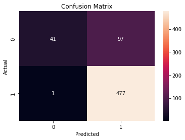

```python
cm=confusion_matrix(ytest_test, score) #you will need to change the latter to your desired output
cm
import seaborn as sns
import matplotlib.pyplot as plt

ax= plt.subplot()
sns.heatmap(cm, annot=True, fmt='g', ax=ax);  #Don't worry too much about the arguments here - we will return to this!

# labels, title and ticks
ax.set_xlabel('Predicted');ax.set_ylabel('Actual');
ax.set_title('Confusion Matrix');
TN, FP, FN, TP = confusion_matrix(ytest_test, score).ravel()

print('True Positive(TP)  = ', TP)
print('False Positive(FP) = ', FP)
print('True Negative(TN)  = ', TN)
print('False Negative(FN) = ', FN)

accuracy =  (TP+TN) /(TP+FP+TN+FN)

print('Accuracy of the binary classification = {:0.3f}'.format(accuracy))
```

Merging Train and Valid data and performing Binary Classification on it.

```python
merged_dfx
```

|  | headline |
| --- | --- |
| 5486 | seaworld just unveiled a new plan to win back ... |
| 7474 | the nightlife in marrakesh, morocco |
| 7827 | a time of vigilance in the ukraine |
| 7540 | never lose your luggage again with these 4 tips |
| 3399 | rep. keith ellison is optimistic about america... |
| ... | ... |
| 2509 | lonely planet's top u.s. destination of 2018 i... |
| 4629 | outrageously lavish hotel suites |
| 2555 | notes from nicaragua: listo or not |
| 7846 | guide to willamette valley wine country (photos) |
| 3765 | bernie sanders embodies trend of the 'spiritua... |

4921 rows × 1 columns

```python
merged_dfy
```

```
0       1.0
1       1.0
2       0.0
3       1.0
4       0.0
       ...
1533    1.0
1534    1.0
1535    1.0
1536    1.0
1537    0.0
Name: category_id, Length: 4921, dtype: float64
```

```python
merged_dfy.unique()
```

```
array([1., 0.])
```

```python
tfidf_vect = TfidfVectorizer(analyzer='word', max_features=3000)

merged_dfx_tfidf = tfidf_vect.fit_transform(merged_dfx['headline'])

merged_dfx_features = pd.DataFrame(merged_dfx_tfidf.toarray())
```

```python
merged_dfx_features
```

|  | 0 | 1 | 2 | 3 | 4 | 5 | 6 | 7 | 8 | 9 | ... | 2990 | 2991 | 2992 | 2993 | 2994 | 2995 | 2996 | 2997 | 2998 | 2999 |
| --- | --- | --- | --- | --- | --- | --- | --- | --- | --- | --- | --- | --- | --- | --- | --- | --- | --- | --- | --- | --- | --- |
| 0 | 0.0 | 0.0 | 0.0 | 0.0 | 0.0 | 0.0 | 0.0 | 0.0 | 0.0 | 0.0 | ... | 0.0 | 0.0 | 0.0 | 0.0 | 0.0 | 0.0 | 0.0 | 0.0 | 0.0 | 0.0 |
| 1 | 0.0 | 0.0 | 0.0 | 0.0 | 0.0 | 0.0 | 0.0 | 0.0 | 0.0 | 0.0 | ... | 0.0 | 0.0 | 0.0 | 0.0 | 0.0 | 0.0 | 0.0 | 0.0 | 0.0 | 0.0 |
| 2 | 0.0 | 0.0 | 0.0 | 0.0 | 0.0 | 0.0 | 0.0 | 0.0 | 0.0 | 0.0 | ... | 0.0 | 0.0 | 0.0 | 0.0 | 0.0 | 0.0 | 0.0 | 0.0 | 0.0 | 0.0 |
| 3 | 0.0 | 0.0 | 0.0 | 0.0 | 0.0 | 0.0 | 0.0 | 0.0 | 0.0 | 0.0 | ... | 0.0 | 0.0 | 0.0 | 0.0 | 0.0 | 0.0 | 0.0 | 0.0 | 0.0 | 0.0 |
| 4 | 0.0 | 0.0 | 0.0 | 0.0 | 0.0 | 0.0 | 0.0 | 0.0 | 0.0 | 0.0 | ... | 0.0 | 0.0 | 0.0 | 0.0 | 0.0 | 0.0 | 0.0 | 0.0 | 0.0 | 0.0 |
| ... | ... | ... | ... | ... | ... | ... | ... | ... | ... | ... | ... | ... | ... | ... | ... | ... | ... | ... | ... | ... | ... |
| 4916 | 0.0 | 0.0 | 0.0 | 0.0 | 0.0 | 0.0 | 0.0 | 0.0 | 0.0 | 0.0 | ... | 0.0 | 0.0 | 0.0 | 0.0 | 0.0 | 0.0 | 0.0 | 0.0 | 0.0 | 0.0 |
| 4917 | 0.0 | 0.0 | 0.0 | 0.0 | 0.0 | 0.0 | 0.0 | 0.0 | 0.0 | 0.0 | ... | 0.0 | 0.0 | 0.0 | 0.0 | 0.0 | 0.0 | 0.0 | 0.0 | 0.0 | 0.0 |
| 4918 | 0.0 | 0.0 | 0.0 | 0.0 | 0.0 | 0.0 | 0.0 | 0.0 | 0.0 | 0.0 | ... | 0.0 | 0.0 | 0.0 | 0.0 | 0.0 | 0.0 | 0.0 | 0.0 | 0.0 | 0.0 |
| 4919 | 0.0 | 0.0 | 0.0 | 0.0 | 0.0 | 0.0 | 0.0 | 0.0 | 0.0 | 0.0 | ... | 0.0 | 0.0 | 0.0 | 0.0 | 0.0 | 0.0 | 0.0 | 0.0 | 0.0 | 0.0 |
| 4920 | 0.0 | 0.0 | 0.0 | 0.0 | 0.0 | 0.0 | 0.0 | 0.0 | 0.0 | 0.0 | ... | 0.0 | 0.0 | 0.0 | 0.0 | 0.0 | 0.0 | 0.0 | 0.0 | 0.0 | 0.0 |

4921 rows × 3000 columns

```python
merged_dfy
```

```
0       1.0
1       1.0
2       0.0
3       1.0
4       0.0
       ...
1533    1.0
1534    1.0
1535    1.0
1536    1.0
1537    0.0
Name: category_id, Length: 4921, dtype: float64
```

```python
x_train_combined, x_test_combined, y_train_combined, y_test_combined = train_test_split(merged_dfx_features, merged_dfy, test_size=0.5)
```

```python
model_rfct = RandomForestClassifier()
model_rfct.fit(x_train_combined, y_train_combined)
dump(model_rfct, open('rfctmodel.pkl', 'wb'))
```

```python
model_rfct = pickle.load(open('rfctmodel.pkl', 'rb'))
```

```python
score = model_rfct.predict(x_test_combined)
result = accuracy_score(y_test_combined,score)
print('Test Accuracy:', result)
```

```
Test Accuracy: 0.8919138561560341
```

Applying saved model from the merged dataset on test dataset

```python
testdata
```

|  | headline | authors | link | short_description | date | news_length | category_id |
| --- | --- | --- | --- | --- | --- | --- | --- |
| 0 | one resolution year | Rabbi Ted Falcon, ContributorSpiritual guide, ... | https://www.huffingtonpost.com/entry/only-one-... | The problem with resolutions is that they prop... | 2015-01-03 | 29.0 | 0.0 |
| 1 | 11 insanely beautiful bodies water photos | Lisa_Miller | https://www.huffingtonpost.com/entry/beautiful... | It's pretty hard to beat sitting lakefront or ... | 2013-06-20 | 46.0 | 1.0 |
| 2 | vacation escapes take mind summers end | Conde Nast Traveler, Contributor\nConde Nast T... | https://www.huffingtonpost.com/entry/vacation-... | A little depressed that summer's winding down?... | 2013-09-09 | 51.0 | 1.0 |
| 3 | embracing tenderloin urban tavern | Anne Z. Cooke, Contributor\nTravel & Feature J... | https://www.huffingtonpost.com/entry/the-urban... | Urban Tavern is in the Tenderloin District, so... | 2012-04-16 | 44.0 | 1.0 |
| 4 | 12 epic sledding hills earth | Cheapflights, Contributorwww.cheapflights.com | https://www.huffingtonpost.com/entry/top-12-ep... | Take advantage of all the wonderful things win... | 2015-02-26 | 40.0 | 1.0 |
| ... | ... | ... | ... | ... | ... | ... | ... |
| 1226 | 7 things thatll still true christians matter h... | Jason Foster, ContributorChristian journalist/... | https://www.huffingtonpost.com/entry/7-things-... | Take a deep breath. Say a prayer. Itâll all ... | 2016-11-06 | 84.0 | 0.0 |
| 1227 | thats airplane windows round | Suzy Strutner | https://www.huffingtonpost.com/entry/plane-win... | It's #science. | 2016-01-20 | 40.0 | 1.0 |
| 1228 | worlds best antiques fair texas | Fathom, Contributor\nGet inspired. Plan your t... | https://www.huffingtonpost.com/entry/the-world... | Twice a year in spring and autumn, people floc... | 2013-09-19 | 42.0 | 1.0 |
| 1229 | tried vegas hangover bus photos | Kaylee King, Contributor\nSenior Editor, Huffi... | https://www.huffingtonpost.com/entry/hangover-... | I hop onboard the bus and am immediately welco... | 2012-06-06 | 39.0 | 1.0 |
| 1230 | cuddling koala australia | Andrea Poe, Contributor\nAndrea Poe is a journ... | https://www.huffingtonpost.com/entry/cuddling-... | Holding a koala is unlike anything you might e... | 2013-06-21 | 29.0 | 1.0 |

1231 rows × 7 columns

```python
model_rfct = pickle.load(open('rfctmodel.pkl', 'rb'))
```

```python
score = model_rfct.predict(xtest_test)
result = accuracy_score(ytest_test,score)
print('Test Accuracy:', result)
```

```
Test Accuracy: 0.5957792207792207
```

# DEEP LEARNING

Source : [Github](https://github.com/rootally/News-Category-Classification-with-BERT/blob/master/Models.ipynb)

```python
#loading the dataset
dataDL = pd.read_csv("20204585.csv",encoding='Latin1',dtype=str)
dataDL.head()
```

|  | Unnamed: 0 | category | headline | authors | link | short_description | date |
| --- | --- | --- | --- | --- | --- | --- | --- |
| 0 | 0 | TRAVEL | The World's Ultimate 'Ski-cations': Exploring ... | HotelsCombined.com, Contributor\nHotel price c... | https://www.huffingtonpost.com/entry/the-world... | From world-famous celeb magnets to quirky and ... | 2014-02-05 |
| 1 | 1 | TRAVEL | Where to Be Daring and Go Baring This Halloween | Tom Mulhall, Contributor\nNude Recreation Spec... | https://www.huffingtonpost.com/entry/where-to-... | Halloween's the scariest time of year for kids... | 2013-10-26 |
| 2 | 2 | TRAVEL | Strange But True: 8 Out of the Ordinary Ski Areas | Liftopia, ContributorSki deals online - www.li... | https://www.huffingtonpost.com/entry/strange-b... | If you are looking for something a little diff... | 2015-02-26 |
| 3 | 3 | TRAVEL | Documenta 13: Disguising Documentary As Art | Olivia Katrandjian, Contributor\nJournalist an... | https://www.huffingtonpost.com/entry/documenta... | The 13th Documenta Festival has taken over Kas... | 2012-08-30 |
| 4 | 4 | TRAVEL | Where To Go This Winter | Fodor's, Contributor\nFodors.com | https://www.huffingtonpost.com/entry/where-to-... | Winter vacations don't always have to be synon... | 2013-12-04 |

```python
dataDL.drop(['Unnamed: 0'],axis=1, inplace = True)
```

```python
dataDL = dataDL.dropna()
```

```python
dataDL
```

|  | category | headline | authors | link | short_description | date |
| --- | --- | --- | --- | --- | --- | --- |
| 0 | TRAVEL | The World's Ultimate 'Ski-cations': Exploring ... | HotelsCombined.com, Contributor\nHotel price c... | https://www.huffingtonpost.com/entry/the-world... | From world-famous celeb magnets to quirky and ... | 2014-02-05 |
| 1 | TRAVEL | Where to Be Daring and Go Baring This Halloween | Tom Mulhall, Contributor\nNude Recreation Spec... | https://www.huffingtonpost.com/entry/where-to-... | Halloween's the scariest time of year for kids... | 2013-10-26 |
| 2 | TRAVEL | Strange But True: 8 Out of the Ordinary Ski Areas | Liftopia, ContributorSki deals online - www.li... | https://www.huffingtonpost.com/entry/strange-b... | If you are looking for something a little diff... | 2015-02-26 |
| 3 | TRAVEL | Documenta 13: Disguising Documentary As Art | Olivia Katrandjian, Contributor\nJournalist an... | https://www.huffingtonpost.com/entry/documenta... | The 13th Documenta Festival has taken over Kas... | 2012-08-30 |
| 4 | TRAVEL | Where To Go This Winter | Fodor's, Contributor\nFodors.com | https://www.huffingtonpost.com/entry/where-to-... | Winter vacations don't always have to be synon... | 2013-12-04 |
| ... | ... | ... | ... | ... | ... | ... |
| 7995 | RELIGION | Muslim Teacher Found A Violent Islamophobic Me... | Carol Kuruvilla | https://www.huffingtonpost.com/entry/muslim-te... | âYour headscarf isnât allowed anymore. Why... | 2016-11-15 |
| 7996 | TRAVEL | The World's 10 Most Expensive Plane Tickets Wi... | Hopper.com, ContributorThe flight-prediction a... | https://www.huffingtonpost.com/entry/the-world... | They are loaded with luxurious add-ons and bes... | 2015-05-27 |
| 7997 | TRAVEL | New U.S. Literary Tourism Goes Beyond 'The Hun... | Reuters, Reuters | https://www.huffingtonpost.com/entry/new-us-li... | "The author is from Jackson, and the book is s... | 2012-04-22 |
| 7998 | TRAVEL | Up For A Challenge? Try These Outdoor Adventur... | Karen Schaler, Contributor\nEmmy award-winning... | https://www.huffingtonpost.com/entry/up-for-a-... | I love chilling out at the beach or a spa as m... | 2012-05-30 |
| 7999 | RELIGION | Church Cross Saves Woman And Grandson Caught I... | Ron Dicker | https://www.huffingtonpost.com/entry/cross-sal... | "I said, 'dear Lord are you taking me home rig... | 2015-10-08 |

6152 rows × 6 columns

```python
cates = dataDL.groupby('category')
print("total categories:", cates.ngroups)
print(cates.size())
```

```
total categories: 2
category
RELIGION    1362
TRAVEL      4790
dtype: int64
```

```python
import re
def clean_str(stringDL):
    """
    Tokenization/string cleaning for dataset
    Every dataset is lower cased except
    """
    stringDL = re.sub(r"[^A-Za-z0-9(),!?\'\`]", " ", stringDL)

    return stringDL.lower()
```

```python
# using headlines

dataDL['text'] = dataDL.headline

# tokenizing the data

tokenizer = Tokenizer()
tokenizer.fit_on_texts(dataDL.text)
xDL = tokenizer.texts_to_sequences(dataDL.text)
dataDL['words'] = xDL

# delete some empty and short data

dataDL['word_length'] = dataDL.words.apply(lambda i: len(i))
dataDL = dataDL[dataDL.word_length >= 5]

dataDL = dataDL.drop(dataDL.columns[[2,3,4,5]], axis=1)

dataDL.shape
#saving the clean data
dataDL.to_csv('cleanedDL.csv',encoding='utf-8')
dataDL.head()
```

|  | category | headline | text | words | word_length |
| --- | --- | --- | --- | --- | --- |
| 0 | TRAVEL | The World's Ultimate 'Ski-cations': Exploring ... | The World's Ultimate 'Ski-cations': Exploring ... | [1, 59, 481, 3982, 3983, 335, 1, 297, 122, 753] | 10 |
| 1 | TRAVEL | Where to Be Daring and Go Baring This Halloween | Where to Be Daring and Go Baring This Halloween | [48, 2, 34, 1593, 7, 105, 3984, 23, 336] | 9 |
| 2 | TRAVEL | Strange But True: 8 Out of the Ordinary Ski Areas | Strange But True: 8 Out of the Ordinary Ski Areas | [937, 153, 616, 71, 76, 5, 1, 2623, 154, 2624] | 10 |
| 3 | TRAVEL | Documenta 13: Disguising Documentary As Art | Documenta 13: Disguising Documentary As Art | [3985, 213, 3986, 2625, 92, 159] | 6 |
| 4 | TRAVEL | Where To Go This Winter | Where To Go This Winter | [48, 2, 105, 23, 122] | 5 |

```python
dataDL1 = pd.read_csv('cleanedDL.csv')
xDL=dataDL1.sample(frac=0.8,random_state=200)
test=dataDL1.drop(xDL.index)
train=xDL.sample(frac=0.8,random_state=200)
val=xDL.drop(train.index)

print(train.shape)
print(val.shape)
print(test.shape)
```

```
(3576, 6)
(894, 6)
(1118, 6)
```

```python
clean_dataDL = pd.read_csv('cleanedDL.csv')
sent_lens = []
sent_nums = []
for idx in range(clean_dataDL.text.shape[0]):
    clean_dataDL.text[idx] = clean_str(clean_dataDL.text[idx])

clean_dataDL.head()
```

|  | Unnamed: 0 | category | headline | text | words | word_length |
| --- | --- | --- | --- | --- | --- | --- |
| 0 | 0 | TRAVEL | The World's Ultimate 'Ski-cations': Exploring ... | the world's ultimate 'ski cations' exploring ... | [1, 59, 481, 3982, 3983, 335, 1, 297, 122, 753] | 10 |
| 1 | 1 | TRAVEL | Where to Be Daring and Go Baring This Halloween | where to be daring and go baring this halloween | [48, 2, 34, 1593, 7, 105, 3984, 23, 336] | 9 |
| 2 | 2 | TRAVEL | Strange But True: 8 Out of the Ordinary Ski Areas | strange but true 8 out of the ordinary ski areas | [937, 153, 616, 71, 76, 5, 1, 2623, 154, 2624] | 10 |
| 3 | 3 | TRAVEL | Documenta 13: Disguising Documentary As Art | documenta 13 disguising documentary as art | [3985, 213, 3986, 2625, 92, 159] | 6 |
| 4 | 4 | TRAVEL | Where To Go This Winter | where to go this winter | [48, 2, 105, 23, 122] | 5 |

```python
train1=dataDL.sample(frac=0.8,random_state=200)
test1=dataDL.drop(train1.index)
```

```python
dataDL.word_length.describe()
```

```
count    5588.000000
mean        8.802255
std         2.738024
min         5.000000
25%         7.000000
50%         8.000000
75%        11.000000
max        26.000000
Name: word_length, dtype: float64
```

Maxlen- maximum length of all sequences

pad_sequences is used to ensure that all sequences in a list have the same length.

To fit the data into any neural network, we need to convert the data into sequence matrices. For this, we are using the pad_sequence module from keras.preprocessing.

```python
from tensorflow.keras.preprocessing import sequence
maxlen = 50
xDL = list(sequence.pad_sequences(dataDL.words, maxlen=maxlen))
```

```python
dataDL
```

|  | category | headline | text | words | word_length |
| --- | --- | --- | --- | --- | --- |
| 0 | TRAVEL | The World's Ultimate 'Ski-cations': Exploring ... | The World's Ultimate 'Ski-cations': Exploring ... | [1, 59, 481, 3982, 3983, 335, 1, 297, 122, 753] | 10 |
| 1 | TRAVEL | Where to Be Daring and Go Baring This Halloween | Where to Be Daring and Go Baring This Halloween | [48, 2, 34, 1593, 7, 105, 3984, 23, 336] | 9 |
| 2 | TRAVEL | Strange But True: 8 Out of the Ordinary Ski Areas | Strange But True: 8 Out of the Ordinary Ski Areas | [937, 153, 616, 71, 76, 5, 1, 2623, 154, 2624] | 10 |
| 3 | TRAVEL | Documenta 13: Disguising Documentary As Art | Documenta 13: Disguising Documentary As Art | [3985, 213, 3986, 2625, 92, 159] | 6 |
| 4 | TRAVEL | Where To Go This Winter | Where To Go This Winter | [48, 2, 105, 23, 122] | 5 |
| ... | ... | ... | ... | ... | ... |
| 7995 | RELIGION | Muslim Teacher Found A Violent Islamophobic Me... | Muslim Teacher Found A Violent Islamophobic Me... | [90, 9362, 925, 4, 9363, 1884, 332, 3, 503, 1649] | 10 |
| 7996 | TRAVEL | The World's 10 Most Expensive Plane Tickets Wi... | The World's 10 Most Expensive Plane Tickets Wi... | [1, 59, 16, 29, 784, 291, 1196, 46, 3731, 11, ... | 11 |
| 7997 | TRAVEL | New U.S. Literary Tourism Goes Beyond 'The Hun... | New U.S. Literary Tourism Goes Beyond 'The Hun... | [18, 68, 69, 2599, 238, 404, 259, 619, 3974, 9... | 10 |
| 7998 | TRAVEL | Up For A Challenge? Try These Outdoor Adventur... | Up For A Challenge? Try These Outdoor Adventur... | [63, 8, 4, 1050, 816, 77, 1041, 257, 35] | 9 |
| 7999 | RELIGION | Church Cross Saves Woman And Grandson Caught I... | Church Cross Saves Woman And Grandson Caught I... | [102, 852, 9365, 738, 7, 9366, 3711, 3, 3329] | 9 |

5588 rows × 5 columns

```python
categories = dataDL.groupby('category').size().index.tolist()
category_int = {}
int_category = {}
for i, k in enumerate(categories):
    category_int.update({k:i})
    int_category.update({i:k})

print(category_int)
print(int_category)
dataDL['c2id'] = dataDL['category'].apply(lambda x: category_int[x])
```

```
{'RELIGION': 0, 'TRAVEL': 1}
{0: 'RELIGION', 1: 'TRAVEL'}
```

Two popular examples of methods of learning word embeddings from text include:

1. Word2Vec.

2. GloVe.

Here we are using GloVe an unsupervised learning algorithm for obtaining vector representations for words. Training is performed on aggregated global word-word co-occurrence statistics from a corpus, and the resulting representations showcase interesting linear substructures of the word vector space.It basically provides 100 dimensinal vector. Every dimension represents different feature of word.

```python
word_index = tokenizer.word_index
EMBEDDING_DIM = 100
# importing the GloVe word embeddings
embeddings_index = {}
f = open('glove.6B.100d.txt',"r",encoding="utf8")
for line in f:
    values = line.split()
    word = ''.join(values[:-100])
    coefs = np.asarray(values[-100:], dtype='float32')
    embeddings_index[word] = coefs
f.close()

print('Found %s unique tokens.' % len(word_index))
print('Total %s word vectors.' % len(embeddings_index))
```

```
Found 9366 unique tokens.
Total 400000 word vectors.
```

Word Embeddings provide a dense representation of words and their relative meanings. They are an improvement over sparse representations used in simpler bag of word model representations.

```python
embedding_matrix = np.zeros((len(word_index) + 1, EMBEDDING_DIM))
for word, i in word_index.items():
    embedding_vector = embeddings_index.get(word)
    if embedding_vector is not None:
        embedding_matrix[i] = embedding_vector

embedding_layer = Embedding(len(word_index)+1,
                            EMBEDDING_DIM,
                            embeddings_initializer=Constant(embedding_matrix),
                            input_length=maxlen,
                            trainable=False) # Initializer for the embeddings matrix
```

```python
xDL = np.array(xDL)
Y = np_utils.to_categorical(list(dataDL.c2id))

# and split to training set and validation set

seed = 29
x_trainDL, x_valDL, y_trainDL, y_valDL = train_test_split(xDL, Y, test_size=0.2, random_state=seed)
```

```python
# Bidrectional LSTM with convolution
# from https://www.kaggle.com/eashish/bidirectional-gru-with-convolution
inp = Input(shape=(maxlen,), dtype='int32')
x = embedding_layer(inp)
x = SpatialDropout1D(0.2)(x)
x = Bidirectional(GRU(128, return_sequences=True, dropout=0.1, recurrent_dropout=0.1))(x)
x = Conv1D(64, kernel_size=3)(x)
avg_pool = GlobalAveragePooling1D()(x)
max_pool = GlobalMaxPooling1D()(x)
x = concatenate([avg_pool, max_pool])
outp = Dense(len(int_category), activation="softmax")(x)

BiGRU = Model(inp, outp)
BiGRU.compile(loss='categorical_crossentropy', optimizer='adam', metrics=['acc'])

BiGRU.summary()
```

```
Model: "model"
__________________________________________________________________________________________________
 Layer (type)                   Output Shape         Param #     Connected to
==================================================================================================
 input_1 (InputLayer)           [(None, 50)]         0           []

 embedding (Embedding)          (None, 50, 100)      936700      ['input_1[0][0]']

 spatial_dropout1d (SpatialDrop  (None, 50, 100)     0           ['embedding[0][0]']
 out1D)

 bidirectional (Bidirectional)  (None, 50, 256)      176640      ['spatial_dropout1d[0][0]']

 conv1d (Conv1D)                (None, 48, 64)       49216       ['bidirectional[0][0]']

 global_average_pooling1d (Glob  (None, 64)          0           ['conv1d[0][0]']
 alAveragePooling1D)

 global_max_pooling1d (GlobalMa  (None, 64)          0           ['conv1d[0][0]']
 xPooling1D)

 concatenate (Concatenate)      (None, 128)          0           ['global_average_pooling1d[0][0]'
                                                                 , 'global_max_pooling1d[0][0]']

 dense (Dense)                  (None, 2)            258         ['concatenate[0][0]']

==================================================================================================
Total params: 1,162,814
Trainable params: 226,114
Non-trainable params: 936,700
__________________________________________________________________________________________________
```

In the next step we will fit the model with data that we loaded from the Keras.

```python
bigru_history = BiGRU.fit(x_trainDL,
                          y_trainDL,
                          batch_size=128,
                          epochs=10,
                          validation_data=(x_valDL, y_valDL))
```

Here we can see that we have trained our model with training data set with 10 epochs. We can use plots to know the model’s performance.

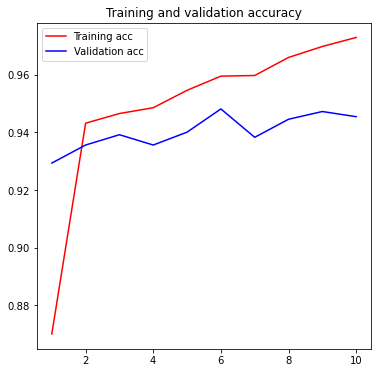

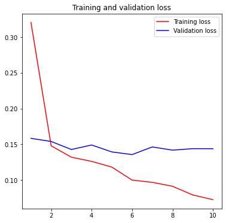

```python
plt.rcParams['figure.figsize'] = (6,6)

acc = bigru_history.history['acc']
val_acc = bigru_history.history['val_acc']
loss = bigru_history.history['loss']
val_loss = bigru_history.history['val_loss']
epochs = range(1, len(acc) + 1)

# comparing the training and validation accuracy
plt.title('Training and validation accuracy')
plt.plot(epochs, acc, 'red', label='Training acc')
plt.plot(epochs, val_acc, 'blue', label='Validation acc')
plt.legend()

# comparing the training and validation loss
plt.figure()
plt.title('Training and validation loss')
plt.plot(epochs, loss, 'red', label='Training loss')
plt.plot(epochs, val_loss, 'blue', label='Validation loss')
plt.legend()

plt.show()
```